# *ChemmineR*: Cheminformatics Toolkit for R

Authors: Kevin Horan, Yiqun Cao, Tyler Backman, Thomas Girke

Last update: 06 March, 2016

#### Package version: ChemmineR 2.23.1

# Contents

Note: the most recent version of this tutorial can be found [here](https://htmlpreview.github.io/?https://github.com/girke-lab/ChemmineR/blob/master/vignettes/ChemmineR.html) and a short overview slide show [here](http://faculty.ucr.edu/~tgirke/HTML_Presentations/Manuals/Workshop_Dec_5_8_2014/Rcheminfo/Cheminfo.pdf).

# 1 Introduction

`ChemmineR` is a cheminformatics package for analyzing drug-like small molecule data in R. Its latest version contains functions for efficient processing of large numbers of small molecules, physicochemical/structural property predictions, structural similarity searching, classification and clustering of compound libraries with a wide spectrum of algorithms.

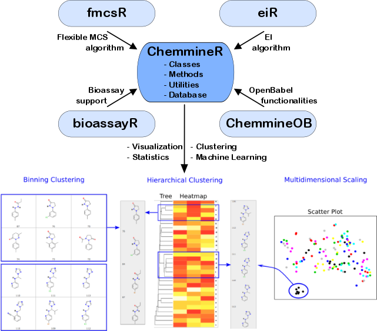

Figure: `ChemmineR` environment with its add-on packages and selected functionalities

**Recently Added Features**

- Improved SMILES support via new `SMIset` object class and SMILES import/export functions
- Integration of a subset of OpenBabel functionalities via new `ChemmineOB` add-on package (Cao et al. 2008)
- Streaming functionality for processing millions of molecules on a laptop
- Mismatch tolerant maximum common substructure (MCS) search algorithm
- Fast and memory efficient fingerprint search support using atom pair or PubChem fingerprints

Back to Table of Contents

# 2 Getting Started

## 2.1 Installation

The R software for running ChemmineR can be downloaded from CRAN (http://cran.at.r-project.org/). The ChemmineR package can be installed from R using the `bioLite` install command.

```r
 source("http://bioconductor.org/biocLite.R") # Sources the biocLite.R installation script.
 biocLite("ChemmineR") # Installs the package.
```

Back to Table of Contents

## 2.2 Loading the Package and Documentation

```r
 library("ChemmineR") # Loads the package
```

```r
 library(help="ChemmineR") # Lists all functions and classes
 vignette("ChemmineR") # Opens this PDF manual from R
```

Back to Table of Contents

## 2.3 Five Minute Tutorial

The following code gives an overview of the most important functionalities provided by `ChemmineR`. Copy and paste of the commands into the R console will demonstrate their utilities.

Create Instances of `SDFset` class:

```r
 data(sdfsample)
 sdfset <- sdfsample
 sdfset # Returns summary of SDFset
```

```
## An instance of "SDFset" with 100 molecules
```

```r
 sdfset[1:4] # Subsetting of object
```

```
## An instance of "SDFset" with 4 molecules
```

```r
 sdfset[[1]] # Returns summarized content of one SDF
```

```
## An instance of "SDF"
##
## <<header>>
##                             Molecule_Name                                    Source
##                                  "650001"                  "  -OEChem-07071010512D"
##                                   Comment                               Counts_Line
##                                        "" " 61 64  0     0  0  0  0  0  0999 V2000"
##
## <<atomblock>>
##           C1      C2  C3  C5  C6  C7  C8  C9 C10 C11 C12 C13 C14 C15 C16
## O_1   7.0468  0.0839   0   0   0   0   0   0   0   0   0   0   0   0   0
## O_2  12.2708  1.0492   0   0   0   0   0   0   0   0   0   0   0   0   0
## ...      ...     ... ... ... ... ... ... ... ... ... ... ... ... ... ...
## H_60  1.8411 -1.5985   0   0   0   0   0   0   0   0   0   0   0   0   0
## H_61  2.6597 -1.2843   0   0   0   0   0   0   0   0   0   0   0   0   0
##
## <<bondblock>>
##      C1  C2  C3  C4  C5  C6  C7
## 1     1  16   2   0   0   0   0
## 2     2  23   1   0   0   0   0
## ... ... ... ... ... ... ... ...
## 63   33  60   1   0   0   0   0
## 64   33  61   1   0   0   0   0
##
## <<datablock>> (33 data items)
##           PUBCHEM_COMPOUND_CID PUBCHEM_COMPOUND_CANONICALIZED      PUBCHEM_CACTVS_COMPLEXITY
##                       "650001"                            "1"                          "700"
##  PUBCHEM_CACTVS_HBOND_ACCEPTOR
##                            "7"                          "..."
```

```r
 view(sdfset[1:4]) # Returns summarized content of many SDFs, not printed here
 as(sdfset[1:4], "list") # Returns complete content of many SDFs, not printed here
```

An `SDFset` is created during the import of an SD file:

```r
 sdfset <- read.SDFset("http://faculty.ucr.edu/ tgirke/Documents/R_BioCond/Samples/sdfsample.sdf")
```

Miscellaneous accessor methods for `SDFset` container:

```r
 header(sdfset[1:4]) # Not printed here
```

```r
 header(sdfset[[1]])
```

```
##                             Molecule_Name                                    Source
##                                  "650001"                  "  -OEChem-07071010512D"
##                                   Comment                               Counts_Line
##                                        "" " 61 64  0     0  0  0  0  0  0999 V2000"
```

```r
 atomblock(sdfset[1:4]) # Not printed here
```

```r
atomblock(sdfset[[1]])[1:4,]
```

```
##          C1     C2 C3 C5 C6 C7 C8 C9 C10 C11 C12 C13 C14 C15 C16
## O_1  7.0468 0.0839  0  0  0  0  0  0   0   0   0   0   0   0   0
## O_2 12.2708 1.0492  0  0  0  0  0  0   0   0   0   0   0   0   0
## O_3 12.2708 3.1186  0  0  0  0  0  0   0   0   0   0   0   0   0
## O_4  7.9128 2.5839  0  0  0  0  0  0   0   0   0   0   0   0   0
```

```r
bondblock(sdfset[1:4]) # Not printed here
```

```r
 bondblock(sdfset[[1]])[1:4,]
```

```
##   C1 C2 C3 C4 C5 C6 C7
## 1  1 16  2  0  0  0  0
## 2  2 23  1  0  0  0  0
## 3  2 27  1  0  0  0  0
## 4  3 25  1  0  0  0  0
```

```r
 datablock(sdfset[1:4]) # Not printed here
```

```r
 datablock(sdfset[[1]])[1:4]
```

```
##           PUBCHEM_COMPOUND_CID PUBCHEM_COMPOUND_CANONICALIZED      PUBCHEM_CACTVS_COMPLEXITY
##                       "650001"                            "1"                          "700"
##  PUBCHEM_CACTVS_HBOND_ACCEPTOR
##                            "7"
```

Assigning compound IDs and keeping them unique:

```r
 cid(sdfset)[1:4] # Returns IDs from SDFset object
```

```
## [1] "CMP1" "CMP2" "CMP3" "CMP4"
```

```r
 sdfid(sdfset)[1:4] # Returns IDs from SD file header block
```

```
## [1] "650001" "650002" "650003" "650004"
```

```r
 unique_ids <- makeUnique(sdfid(sdfset))
```

```
## [1] "No duplicates detected!"
```

```r
 cid(sdfset) <- unique_ids
```

Converting the data blocks in an `SDFset` to a matrix:

```r
 blockmatrix <- datablock2ma(datablocklist=datablock(sdfset)) # Converts data block to matrix
 numchar <- splitNumChar(blockmatrix=blockmatrix) # Splits to numeric and character matrix
 numchar[[1]][1:2,1:2] # Slice of numeric matrix
```

```
##        PUBCHEM_COMPOUND_CID PUBCHEM_COMPOUND_CANONICALIZED
## 650001               650001                              1
## 650002               650002                              1
```

```r
 numchar[[2]][1:2,10:11] # Slice of character matrix
```

```
##        PUBCHEM_MOLECULAR_FORMULA PUBCHEM_OPENEYE_CAN_SMILES
## 650001 "C23H28N4O6"              "CC1=CC(=NO1)NC(=O)CCC(=O)N(CC(=O)NC2CCCC2)C3=CC4=C(C=C3)OCCO4"
## 650002 "C18H23N5O3"              "CN1C2=C(C(=O)NC1=O)N(C(=N2)NCCCO)CCCC3=CC=CC=C3"
```

Compute atom frequency matrix, molecular weight and formula:

```r
 propma <- data.frame(MF=MF(sdfset), MW=MW(sdfset), atomcountMA(sdfset))
 propma[1:4, ]
```

```
##                 MF       MW  C  H N O S F Cl
## 650001  C23H28N4O6 456.4916 23 28 4 6 0 0  0
## 650002  C18H23N5O3 357.4069 18 23 5 3 0 0  0
## 650003 C18H18N4O3S 370.4255 18 18 4 3 1 0  0
## 650004 C21H27N5O5S 461.5346 21 27 5 5 1 0  0
```

Assign matrix data to data block:

```r
 datablock(sdfset) <- propma
 datablock(sdfset[1])
```

```
## $`650001`
##           MF           MW            C            H            N            O            S
## "C23H28N4O6"   "456.4916"         "23"         "28"          "4"          "6"          "0"
##            F           Cl
##          "0"          "0"
```

String searching in `SDFset`:

```r
 grepSDFset("650001", sdfset, field="datablock", mode="subset") # Returns summary view of matches. Not printed here.
```

```r
 grepSDFset("650001", sdfset, field="datablock", mode="index")
```

```
## 1 1 1 1 1 1 1 1 1
## 1 2 3 4 5 6 7 8 9
```

Export SDFset to SD file:

```r
 write.SDF(sdfset[1:4], file="sub.sdf", sig=TRUE)
```

Plot molecule structure of one or many SDFs:

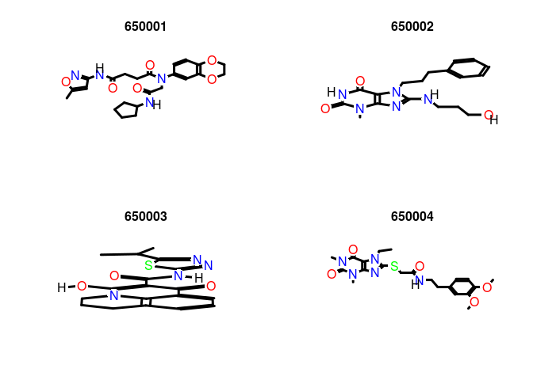

```r
 plot(sdfset[1:4], print=FALSE) # Plots structures to R graphics device
```

```r
 sdf.visualize(sdfset[1:4]) # Compound viewing in web browser
```

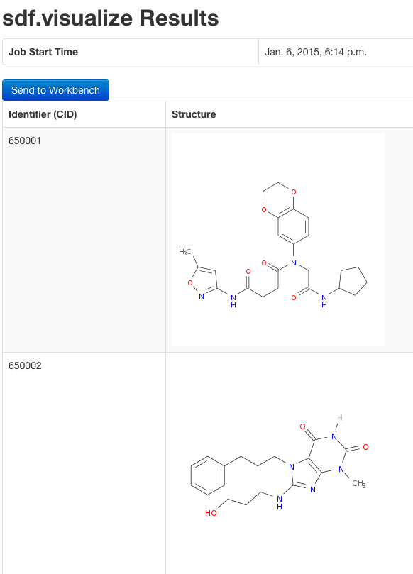

Figure: Visualization webpage created by calling`sdf.visualize`.

Structure similarity searching and clustering:

```r
 apset <- sdf2ap(sdfset) # Generate atom pair descriptor database for searching
```

```r
 data(apset) # Load sample apset data provided by library.
 cmp.search(apset, apset[1], type=3, cutoff = 0.3, quiet=TRUE) # Search apset database with single compound.
```

```
##   index    cid    scores
## 1     1 650001 1.0000000
## 2    96 650102 0.3516643
## 3    67 650072 0.3117569
## 4    88 650094 0.3094629
## 5    15 650015 0.3010753
```

```r
 cmp.cluster(db=apset, cutoff = c(0.65, 0.5), quiet=TRUE)[1:4,] # Binning clustering using variable similarity cutoffs.
```

```
##
## sorting result...
```

```
##       ids CLSZ_0.65 CLID_0.65 CLSZ_0.5 CLID_0.5
## 48 650049         2        48        2       48
## 49 650050         2        48        2       48
## 54 650059         2        54        2       54
## 55 650060         2        54        2       54
```

Back to Table of Contents

# 3 OpenBabel Functions

`ChemmineR` integrates now a subset of cheminformatics functionalities implemented in the OpenBabel C++ library (O’Boyle, Morley, and Hutchison 2008; Cao et al. 2008). These utilities can be accessed by installing the `ChemmineOB` package and the OpenBabel software itself. `ChemmineR` will automatically detect the availability of `ChemmineOB` and make use of the additional utilities. The following lists the functions and methods that make use of OpenBabel. References are included to locate the sections in the manual where the utility and usage of these functions is described.

*Structure format interconversions* (see Section Format Inter-Conversions)

- `smiles2sdf`: converts from SMILES to SDF object
- `sdf2smiles`: converts from SDF to SMILES object
- `convertFormat`: converts strings between two formats
- `convertFormatFile`: converts files between two formats. This function can be used to enable ChemmineR to read in any format supported by Open Babel. For example, if you had an SML file you could do:

```r
convertFormatFile("SML","SDF","mycompound.sml","mycompound.sdf")
sdfset=read.SDFset("mycompound.sdf")
```

`propOB`: generates several compound properties. See the man page for a current list of properties computed.

```r
propOB(sdfset[1])
```

```
##                                                          cansmi
## 650001 O=C(Nc1noc(c1)C)CCC(=O)N(c1ccc2c(c1)OCCO2)CC(=O)NC1CCCC1
##                                                        cansmiNS    formula  title
## 650001 O=C(Nc1noc(c1)C)CCC(=O)N(c1ccc2c(c1)OCCO2)CC(=O)NC1CCCC1 C23H28N4O6 650001
##                                                                                                                                                                                    InChI
## 650001 InChI=1S/C23H28N4O6/c1-15-12-20(26-33-15)25-21(28)8-9-23(30)27(14-22(29)24-16-4-2-3-5-16)17-6-7-18-19(13-17)32-11-10-31-18/h6-7,12-13,16H,2-5,8-11,14H2,1H3,(H,24,29)(H,25,26,28)
##        HBA1 HBA2 HBD   logP       MR       MW nF TPSA
## 650001   37   10   2 3.0288 119.9234 456.4916  0  123
```

`fingerprintOB`: generates fingerprints for compounds. The fingerprint name can be anything supported by OpenBabel. See the man page for a current list.

```r
fingerprintOB(sdfset,"FP2")
```

```
## An instance of a 1024 bit "FPset" of type "FP2" with 100 molecules
```

`smartsSearchOB`: find matches of SMARTS patterns in compounds

```r
#count rotable bonds
smartsSearchOB(sdfset[1:5],"[!$(*#*)&!D1]-!@[!$(*#*)&!D1]",uniqueMatches=FALSE)
```

```
## 650001 650002 650003 650004 650005
##     24     20     14     30     10
```

`exactMassOB`: Compute the monoisotopic (exact) mass of a set of compounds

```r
exactMassOB(sdfset[1:5])
```

```
##   650001   650002   650003   650004   650005
## 456.2009 357.1801 370.1100 461.1733 318.1943
```

`regenerateCoords`: Re-compute the 2D coordinates of a compound using Open Babel. This can sometimes improve the quality of the compounds plot. See also the `regenCoords` option of the plot function.

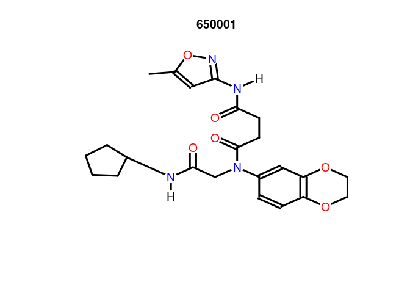

```r
sdfset2 = regenerateCoords(sdfset[1:5])

plot(sdfset[1], regenCoords=TRUE,print=FALSE)
```

`generate3DCoords`: Generate 3D coordinates for compounds with only 2D coordinates.

```r
sdf3D = generate3DCoords(sdfset[1])
```

`canonicalize`: Compute a canonicalized atom numbering. This allows compounds with the same molecular structure but different atom numberings to be compared properly.

```r
canonicalSdf= canonicalize(sdfset[1])
```

`canonicalNumbering`: Return a mapping from the original atom numbering to the canonical atom number.

```r
mapping = canonicalNumbering(sdfset[1])
```

Back to Table of Contents

# 4 Overview of Classes and Functions

The following list gives an overview of the most important S4 classes, methods and functions available in the ChemmineR package. The help documents of the package provide much more detailed information on each utility. The standard R help documents for these utilities can be accessed with this syntax: `?function\_name` (*e.g.* `?cid`) and `?class\_name-class` (*e.g*. `?"SDFset-class"`).

Back to Table of Contents

## 4.1 Molecular Structure Data

Classes

- `SDFstr`: intermediate string class to facilitate SD file import; not important for end user
- `SDF`: container for single molecule imported from an SD file
- `SDFset`: container for many SDF objects; most important structure container for end user
- `SMI`: container for a single SMILES string
- `SMIset`: container for many SMILES strings

Functions/Methods (mainly for `SDFset` container, `SMIset` should be coerced with `smiles2sd` to `SDFset`)

- Accessor methods for `SDF/SDFset`
  - Object slots: `cid`, `header`, `atomblock`, `bondblock`, `datablock` (`sdfid`, `datablocktag`)
  - Summary of `SDFset`: `view`
  - Matrix conversion of data block: `datablock2ma`, `splitNumChar`
  - String search in SDFset: `grepSDFset`
- Coerce one class to another
  - Standard syntax `as(..., "...")` works in most cases. For details see R help with `?"SDFset-class"`.
- Utilities
  - Atom frequencies: `atomcountMA`, `atomcount`
  - Molecular weight: `MW`
  - Molecular formula: `MF`
  - …
- Compound structure depictions
  - R graphics device: `plot`, `plotStruc`
  - Online: `cmp.visualize`

Back to Table of Contents

## 4.2 Structure Descriptor Data

Classes

- `AP`: container for atom pair descriptors of a single molecule
- `APset`: container for many AP objects; most important structure descriptor container for end user
- `FP`: container for fingerprint of a single molecule
- `FPset`: container for fingerprints of many molecules, most important structure descriptor container for end user

Functions/Methods

- Create `AP/APset` instances
  - From `SDFset`: `sdf2ap`
  - From SD file: `cmp.parse`
  - Summary of `AP/APset`: `view`, `db.explain`
- Accessor methods for AP/APset
  - Object slots: `ap`, `cid`
- Coerce one class to another
  - Standard syntax `as(..., "...")` works in most cases. For details see R help with `?"APset-class"`.
- Structure Similarity comparisons and Searching
  - Compute pairwise similarities : `cmp.similarity`, `fpSim`
  - Search APset database: `cmp.search`, `fpSim`
- AP-based Structure Similarity Clustering
  - Single-linkage binning clustering: `cmp.cluster`
  - Visualize clustering result with MDS: `cluster.visualize`
  - Size distribution of clusters: `cluster.sizestat`
- Folding
  - Fold a descriptor with `fold`
  - Query the number of times a descriptor has been folded: `foldCount`
  - Query the number of bits in a descriptor: `numBits`

Back to Table of Contents

# 5 Import of Compounds

## 5.1 SDF Import

The following gives an overview of the most important import/export functionalities for small molecules provided by `ChemmineR`. The given example creates an instance of the `SDFset` class using as sample data set the first 100 compounds from this PubChem SD file (SDF): Compound_00650001_00675000.sdf.gz (ftp://ftp.ncbi.nih.gov/pubchem/Compound/CURRENT-Full/SDF/).

SDFs can be imported with the `read.SDFset` function:

```r
 sdfset <- read.SDFset("http://faculty.ucr.edu/ tgirke/Documents/R_BioCond/Samples/sdfsample.sdf")
```

```r
 data(sdfsample) # Loads the same SDFset provided by the library
 sdfset <- sdfsample
 valid <- validSDF(sdfset) # Identifies invalid SDFs in SDFset objects
 sdfset <- sdfset[valid] # Removes invalid SDFs, if there are any
```

Import SD file into `SDFstr` container:

```r
 sdfstr <- read.SDFstr("http://faculty.ucr.edu/ tgirke/Documents/R_BioCond/Samples/sdfsample.sdf")
```

Create `SDFset` from `SDFstr` class:

```r
 sdfstr <- as(sdfset, "SDFstr")
 sdfstr
```

```
## An instance of "SDFstr" with 100 molecules
```

```r
 as(sdfstr, "SDFset")
```

```
## An instance of "SDFset" with 100 molecules
```

Back to Table of Contents

## 5.2 SMILES Import

The `read.SMIset` function imports one or many molecules from a SMILES file and stores them in a `SMIset` container. The input file is expected to contain one SMILES string per row with tab-separated compound identifiers at the end of each line. The compound identifiers are optional.

Create sample SMILES file and then import it:

```r
 data(smisample); smiset <- smisample
 write.SMI(smiset[1:4], file="sub.smi")
 smiset <- read.SMIset("sub.smi")
```

Inspect content of `SMIset`:

```r
 data(smisample) # Loads the same SMIset provided by the library
 smiset <- smisample
 smiset
```

```
## An instance of "SMIset" with 100 molecules
```

```r
 view(smiset[1:2])
```

```
## $`650001`
## An instance of "SMI"
## [1] "O=C(NC1CCCC1)CN(c1cc2OCCOc2cc1)C(=O)CCC(=O)Nc1noc(c1)C"
##
## $`650002`
## An instance of "SMI"
## [1] "O=c1[nH]c(=O)n(c2nc(n(CCCc3ccccc3)c12)NCCCO)C"
```

Accessor functions:

```r
 cid(smiset[1:4])
```

```
## [1] "650001" "650002" "650003" "650004"
```

```r
 smi <- as.character(smiset[1:2])
```

Create `SMIset` from named character vector:

```r
 as(smi, "SMIset")
```

```
## An instance of "SMIset" with 2 molecules
```

Back to Table of Contents

# 6 Export of Compounds

## 6.1 SDF Export

Write objects of classes `SDFset/SDFstr/SDF` to SD file:

```r
 write.SDF(sdfset[1:4], file="sub.sdf")
```

Writing customized `SDFset` to file containing `ChemmineR` signature, IDs from `SDFset` and no data block:

```r
 write.SDF(sdfset[1:4], file="sub.sdf", sig=TRUE, cid=TRUE, db=NULL)
```

Example for injecting a custom matrix/data frame into the data block of an `SDFset` and then writing it to an SD file:

```r
 props <- data.frame(MF=MF(sdfset), MW=MW(sdfset), atomcountMA(sdfset))
 datablock(sdfset) <- props
 write.SDF(sdfset[1:4], file="sub.sdf", sig=TRUE, cid=TRUE)
```

Indirect export via `SDFstr` object:

```r
 sdf2str(sdf=sdfset[[1]], sig=TRUE, cid=TRUE) # Uses default components
 sdf2str(sdf=sdfset[[1]], head=letters[1:4], db=NULL) # Uses custom components for header and data block
```

Write `SDF`, `SDFset` or `SDFstr` classes to file:

```r
 write.SDF(sdfset[1:4], file="sub.sdf", sig=TRUE, cid=TRUE, db=NULL)
 write.SDF(sdfstr[1:4], file="sub.sdf")
 cat(unlist(as(sdfstr[1:4], "list")), file="sub.sdf", sep="")
```

Back to Table of Contents

## 6.2 SMILES Export

Write objects of class `SMIset` to SMILES file with and without compound identifiers:

```r
 data(smisample); smiset <- smisample # Sample data set

 write.SMI(smiset[1:4], file="sub.smi", cid=TRUE) write.SMI(smiset[1:4], file="sub.smi", cid=FALSE)
```

Back to Table of Contents

# 7 Format Interconversions

The `sdf2smiles` and `smiles2sdf` functions provide format interconversion between SMILES strings (Simplified Molecular Input Line Entry Specification) and `SDFset` containers.

Convert an `SDFset` container to a SMILES `character` string:

```r
 data(sdfsample);
 sdfset <- sdfsample[1]
 smiles <- sdf2smiles(sdfset)
 smiles
```

Convert a SMILES `character` string to an `SDFset` container:

```r
 sdf <- smiles2sdf("CC(=O)OC1=CC=CC=C1C(=O)O")
 view(sdf)
```

When the `ChemineOB` package is installed these conversions are performed with the OpenBabel Open Source Chemistry Toolbox. Otherwise the functions will fall back to using the ChemMine Tools web service for this operation. The latter will require internet connectivity and is limited to only the first compound given. `ChemmineOB` provides access to the compound format conversion functions of OpenBabel. Currently, over 160 formats are supported by OpenBabel. The functions `convertFormat` and `convertFormatFile` can be used to convert files or strings between any two formats supported by OpenBabel. For example, to convert a SMILES string to an SDF string, one can use the `convertFormat` function.

```r
 sdfStr <- convertFormat("SMI","SDF","CC(=O)OC1=CC=CC=C1C(=O)O_name")
```

This will return the given compound as an SDF formatted string. 2D coordinates are also computed and included in the resulting SDF string.

To convert a file with compounds encoded in one format to another format, the `convertFormatFile` function can be used instead.

```r
 convertFormatFile("SMI","SDF","test.smiles","test.sdf")
```

To see the whole list of file formats supported by OpenBabel, one can run from the command-line “obabel -L formats”.

Back to Table of Contents

# 8 Splitting SD Files

The following `write.SDFsplit` function allows to split SD Files into any number of smaller SD Files. This can become important when working with very big SD Files. Users should note that this function can output many files, thus one should run it in a dedicated directory!

Create sample SD File with 100 molecules:

```r
 write.SDF(sdfset, "test.sdf")
```

Read in sample SD File. Note: reading file into SDFstr is much faster than into SDFset:

```r
 sdfstr <- read.SDFstr("test.sdf")
```

Run export on `SDFstr` object:

```r
 write.SDFsplit(x=sdfstr, filetag="myfile", nmol=10) # 'nmol' defines the number of molecules to write to each file
```

Run export on `SDFset` object:

```r
 write.SDFsplit(x=sdfset, filetag="myfile", nmol=10)
```

Back to Table of Contents

# 9 Streaming Through Large SD Files

The `sdfStream` function allows to stream through SD Files with millions of molecules without consuming much memory. During this process any set of descriptors, supported by `ChemmineR`, can be computed (*e.g.* atom pairs, molecular properties, etc.), as long as they can be returned in tabular format. In addition to descriptor values, the function returns a line index that gives the start and end positions of each molecule in the source SD File. This line index can be used by the downstream `read.SDFindex` function to retrieve specific molecules of interest from the source SD File without reading the entire file into R. The following outlines the typical workflow of this streaming functionality in `ChemmineR`.

Create sample SD File with 100 molecules:

```r
 write.SDF(sdfset, "test.sdf")
```

Define descriptor set in a simple function:

```r
 desc <- function(sdfset)
 cbind(SDFID=sdfid(sdfset),
    # datablock2ma(datablocklist=datablock(sdfset)),
     MW=MW(sdfset),
    groups(sdfset), APFP=desc2fp(x=sdf2ap(sdfset), descnames=1024,
    type="character"), AP=sdf2ap(sdfset, type="character"), rings(sdfset,
    type="count", upper=6, arom=TRUE) )
```

Run `sdfStream` with `desc` function and write results to a file called `matrix.xls`:

```r
 sdfStream(input="test.sdf", output="matrix.xls", fct=desc, Nlines=1000) # 'Nlines': number of lines to read from input SD File at a time
```

One can also start reading from a specific line number in the SD file. The following example starts at line number 950. This is useful for restarting and debugging the process. With `append=TRUE` the result can be appended to an existing file.

```r
 sdfStream(input="test.sdf", output="matrix2.xls", append=FALSE, fct=desc, Nlines=1000, startline=950)
```

Select molecules meeting certain property criteria from SD File using line index generated by previous `sdfStream` step:

```r
 indexDF <- read.delim("matrix.xls", row.names=1)[,1:4]
 indexDFsub <- indexDF[indexDF$MW < 400, ] # Selects molecules with MW < 400
 sdfset <- read.SDFindex(file="test.sdf", index=indexDFsub, type="SDFset") # Collects results in 'SDFset' container
```

Write results directly to SD file without storing larger numbers of molecules in memory:

```r
 read.SDFindex(file="test.sdf", index=indexDFsub, type="file",
 outfile="sub.sdf")
```

Read AP/APFP strings from file into `APset` or `FP` object:

```r
 apset <- read.AP(x="matrix.xls", type="ap", colid="AP")
 apfp <- read.AP(x="matrix.xls", type="fp", colid="APFP")
```

Alternatively, one can provide the AP/APFP strings in a named character vector:

```r
 apset <- read.AP(x=sdf2ap(sdfset[1:20], type="character"), type="ap")
 fpchar <- desc2fp(sdf2ap(sdfset[1:20]), descnames=1024, type="character")
 fpset <- as(fpchar, "FPset")
```

Back to Table of Contents

# 10 Storing Compounds in an SQL Database

As an alternative to sdfStream, there is now also an option to store data in an SQL database, which then allows for fast queries and compound retrieval. The default database is SQLite, but any other SQL database should work with some minor modifications to the table definitions, which are stored in schema/compounds.SQLite under the ChemmineR package directory. Compounds are stored in their entirety in the databases so there is no need to keep any original data files.

Users can define their own set of compound features to compute and store when loading new compounds. Each of these features will be stored in its own, indexed table. Searches can then be performed using these features to quickly find specific compounds. Compounds can always be retrieved quickly because of the database index, no need to scan a large compound file. In addition to user defined features, descriptors can also be computed and stored for each compound.

A new database can be created with the `initDb` function. This takes either an existing database connection, or a filename. If a filename is given then an SQLite database connection is created. It then ensures that the required tables exist and creates them if not. The connection object is then returned. This function can be called safely on the same connection or database many times and will not delete any data.

Back to Table of Contents

## 10.1 Loading Data

The functions `loadSdf` and `loadSmiles` can be used to load compound data from either a file (both) or an `SDFset` (`loadSdf` only). The `fct` parameter should be a function to extract features from the data. It will be handed an `SDFset` generated from the data being loaded. This may be done in batches, so there is no guarantee that the given SDFSset will contain the whole dataset. This function should return a data frame with a column for each feature and a row for each compound given. The order of the final data frame should be the same as that of the `SDFset`. The column names will become the feature names. Each of these features will become a new, indexed, table in the database which can be used later to search for compounds.

The `descriptors` parameter can be a function which computes descriptors. This function will also be given an `SDFset` object, which may be done in batches. It should return a data frame with the following two columns: “descriptor” and “descriptor_type”. The “descriptor” column should contain a string representation of the descriptor, and “descriptor_type” is the type of the descriptor. Our convention for atom pair is “ap” and “fp” for finger print. The order should also be maintained.

When the data has been loaded, `loadSdf` will return the compound id numbers of each compound loaded. These compound id numbers are computed by the database and are not extracted from the compound data itself. They can be used to quickly retrieve compounds later.

New features can also be added using this function. However, all compounds must have all features so if new features are added to a new set of compounds, all existing features must be computable by the `fct` function given. If new features are detected, all existing compounds will be run through `fct` in order to compute the new features for them as well.

For example, if dataset X is loaded with features F1 and F2, and then at a later time we load dataset Y with new feature F3, the `fct` function used to load dataset Y must compute and return features F1, F2, and F3. `loadSdf` will call `fct` with both datasets X and Y so that all features are available for all compounds. If any features are missing an error will be raised. If just new features are being added, but no new compounds, use the `addNewFeatures` function.

In this example, we create a new database called “test.db” and load it with data from an `SDFset`. We also define `fct` to compute the molecular weight, “MW”, and the number of rings and aromatic rings. The rings function actually returns a data frame with columns “RINGS” and “AROMATIC”, which will be merged into the data frame being created which will also contain the “MW” column. These will be the names used for these features and must be used when searching with them. Finally, the new compound ids are returned and stored in the “ids” variable.

```r
 data(sdfsample)

 #create and initialize a new SQLite database
 conn <- initDb("test.db")
 # load data and compute 3 features: molecular weight, with the MW function,
 # and counts for RINGS and AROMATIC, as computed by rings, which
 # returns a data frame itself.
 ids<-loadSdf(conn,sdfsample, function(sdfset)
                     data.frame(rings(sdfset,type="count",upper=6, arom=TRUE),propOB(sdfset)) )

 #list features in the database:
 print(listFeatures(conn))
```

```
##  [1] "aromatic" "cansmi"   "cansmins" "formula"  "hba1"     "hba2"     "hbd"      "inchi"
##  [9] "logp"     "mr"       "mw"       "nf"       "rings"    "title"    "tpsa"
```

Back to Table of Contents

## 10.2 Updates

By default the `loadSdf` / `loadSmiles` functions will detect duplicate compound entries and only insert one of them. This means it is safe to run these functions on the same data set several times and you won’t end up with duplicates. This allows the functions to be re-run in the event that a previous run on a dataset does not complete. Duplicate compounds are detected by compouting the MD5 checksum on the textual representation of it.

It can also update existing compounds with new versions of the same compound. To enable this, set `updateByName` to true. It will then consider two compounds with the same name to be the same, even if the definition is different. Then, if the name of a compound exists in the database and it is trying to insert another compound with the same name, it will overwrite the existing compound. It will also drop and re-compute all associated descriptors and features for the new compound (assuming the required functions for descriptor and feature computation are available at the time the update is performed).

Back to Table of Contents

## 10.3 Duplicate Descriptors

It is often the case when loading a large set of compounds that several compounds will produce the same descriptor. `ChemmineR` detects this case and only stores one copy of the descriptor for every compound it is for. This feature saves some space and some time for processes that need to be applied to every descriptor. It also highlights a new problem. If you have a descriptor in hand and you want to find a single compound to represent it, which compound should be used if the descriptor was produced from multiple compounds? To address this problem, `ChemmineR` allows you to set priority values for each compound-descriptor mapping. Then, in contexts where a single compound is required, the highest priority compound will be chosen. Highest priority corresponds to the lowest numerical value. So mapping with priority 0 would be used first.

To set these priorities there is the function `setPriorities`. It takes a function, `priorityFn`, for computing these priority values. The `setPriorities` function should be run after loading a complete set of data. It will find each group of compounds which share the same descriptor and call the given function, `priorityFn`, with the compound_id numbers of the group. This function should then assign priorities to each compound-descriptor pair, however it wishes.

One built in priority function is `forestSizePriorities`. This simply prefers compounds with fewer disconnected components over compounds with more dissconnected components.

```r
setPriorities(conn,forestSizePriorities)
```

Back to Table of Contents

## 10.4 Searching

Compounds can be searched for using the `findCompounds` function. This function takes a connection object, a vector of feature names used in the tests, and finally, a vector of tests that must all pass for a compound to be included in the result set. Each test should be a boolean expression. For example: `c("MW <= 400","RINGS \> 3")` would return all compounds with a molecular weight of 400 or less and more than 3 rings, assuming these features exist in the database. The syntax for each test is `'\<feature name\> \<SQL operator\> \<value\>'`. If you know SQL you can go beyond this basic syntax. These tests will simply be concatenated together with “AND” in-between them and tacked on the end of a WHERE clause of an SQL statement. So any SQL that will work in that context is fine. The function will return a list of compound ids, the actual compounds can be fetched with `getCompounds`. If just the names are needed, the `getCompoundNames` function can be used. Compounds can also be fetched by name using the `findCompoundsByName` function.

In this example we search for compounds with molecular weight less than 300.

```r
results = findCompounds(conn,"mw",c("mw < 300"))
message("found ",length(results))
```

```
## found 23
```

If more than one test is given, only compounds which satisfy all tests are found. So if we wanted to further restrict our search to compounds with 2 or more aromatic rings we could do:

```r
results = findCompounds(conn,c("mw","aromatic"),c("mw < 300","aromatic >= 2"))
message("found ",length(results))
```

```
## found 9
```

Remember that any feature used in some test must be listed in the second argument.

String patterns can also be used. So if we wanted to match a substring of the molecular formula, say to find compounds with 21 carbon atoms, we could do:

```r
results = findCompounds(conn,"formula",c("formula like '%C21%'"))
message("found ",length(results))
```

```
## found 12
```

The “like” operator does a pattern match. There are two wildcard operators that can be used with this operator. The “%” will match any stretch of characters while the “?” will match any single character. So the above expression would match a formula like “C21H28N4O6”.

Valid comparison operators are:

- <, <=, > , >=
- =, ==, !=, <>, IS, IS NOT, IN, LIKE

The boolean operators “AND” and “OR” can also be used to create more complex expressions within a single test.

If you just want to fetch every compound in the database you can use the `getAllCompoundIds` function:

```r
allIds = getAllCompoundIds(conn)
message("found ",length(allIds))
```

```
## found 100
```

Back to Table of Contents

## 10.5 Using Search Results

Once you have a list of compound ids from the `findCompounds` function, you can either fetch the compound names, or the whole set of compounds as an SDFset.

```r
#get the names of the compounds:
names = getCompoundNames(conn,results)

#if the name order is important set keepOrder=TRUE
#It will take a little longer though
names = getCompoundNames(conn,results,keepOrder=TRUE)


# get the whole set of compounds
compounds = getCompounds(conn,results)
#in order:
compounds = getCompounds(conn,results,keepOrder=TRUE)
#write results directly to a file:
compounds = getCompounds(conn,results,filename=file.path(tempdir(),"results.sdf"))
```

Using the `getCompoundFeatures` function, you can get a set of feature values as a data frame:

```r
getCompoundFeatures(conn,results[1:5],c("mw","logp","formula"))
```

```
##   compound_id       mw   logp       formula
## 1         204 461.5346 1.3127   C21H27N5O5S
## 2         208 438.4780 3.5492  C21H19FN6O2S
## 3         221 340.4592 3.1325    C21H28N2O2
## 4         238 447.9351 5.2940 C21H22ClN3O4S
## 5         243 456.5181 3.0020   C21H24N6O4S
```

```r
#write results directly to a CSV file (reduces memory usage):
getCompoundFeatures(conn,results[1:5],c("mw","logp","formula"),filename="features.csv")

#maintain input order in output:
print(results[1:5])
```

```
## [1] 204 208 221 238 243
```

```r
getCompoundFeatures(conn,results[1:5],c("mw","logp","formula"),keepOrder=TRUE)
```

```
##     compound_id       mw   logp       formula
## 204         204 461.5346 1.3127   C21H27N5O5S
## 208         208 438.4780 3.5492  C21H19FN6O2S
## 221         221 340.4592 3.1325    C21H28N2O2
## 238         238 447.9351 5.2940 C21H22ClN3O4S
## 243         243 456.5181 3.0020   C21H24N6O4S
```

Back to Table of Contents

## 10.6 Pre-Built Databases

We have pre-built SQLite databases for the Drug Bank and DUD datasets. They can be found in the ChemmineDrugs annotation package. Connections to these databases can be fetched from the functions `DrugBank` and `DUD` to get the corresponding database. Any of the above functions can then be used to query the database.

The DUD dataset was downloaded from [here](http://dude.docking.org/db/subsets/all/all.tar.gz). A description can be found [here](http://dude.docking.org/).

The Drug Bank data set is version 4.1. It can be downloaded [here](http://www.drugbank.ca/system/downloads/current/structures/all.sdf.zip)

The following features are included:

- **aromatic**: Number of aromatic rings
- **cansmi**: Canonical SMILES sting
- **cansmins**:
- **formula**: Molecular formula
- **hba1**:
- **hba2**:
- **hbd**:
- **inchi**: INCHI string
- **logp**:
- **mr**:
- **mw**: Molecular weight
- **ncharges**:
- **nf**:
- **r2nh**:
- **r3n**:
- **rcch**:
- **rcho**:
- **rcn**:
- **rcooh**:
- **rcoor**:
- **rcor**:
- **rings**:
- **rnh2**:
- **roh**:
- **ropo3**:
- **ror**:
- **title**:
- **tpsa**:

The DUD database additionally includes:

- **target_name**: Name of the target
- **type**: either “active” or “decoy”

Back to Table of Contents

# 11 Working with SDF/SDFset Classes

Several methods are available to return the different data components of `SDF/SDFset` containers in batches. The following examples list the most important ones. To save space their content is not printed in the manual.

```r
 view(sdfset[1:4]) # Summary view of several molecules

 length(sdfset) # Returns number of molecules
 sdfset[[1]] # Returns single molecule from SDFset as SDF object

 sdfset[[1]][[2]] # Returns atom block from first compound as matrix

 sdfset[[1]][[2]][1:4,]
 c(sdfset[1:4], sdfset[5:8]) # Concatenation of several SDFsets
```

The `grepSDFset` function allows string matching/searching on the different data components in `SDFset`. By default the function returns a SDF summary of the matching entries. Alternatively, an index of the matches can be returned with the setting `mode="index"`.

```r
 grepSDFset("650001", sdfset, field="datablock", mode="subset") # To return index, set mode="index")
```

Utilities to maintain unique compound IDs:

```r
 sdfid(sdfset[1:4]) # Retrieves CMP IDs from Molecule Name field in header block.
 cid(sdfset[1:4]) # Retrieves CMP IDs from ID slot in SDFset.
 unique_ids <- makeUnique(sdfid(sdfset)) # Creates unique IDs by appending a counter to duplicates.
 cid(sdfset) <- unique_ids # Assigns uniquified IDs to ID slot
```

Subsetting by character, index and logical vectors:

```r
 view(sdfset[c("650001", "650012")])
 view(sdfset[4:1])
 mylog <- cid(sdfset)
 view(sdfset[mylog])
```

Accessing `SDF/SDFset` components: header, atom, bond and data blocks:

```r
 atomblock(sdf); sdf[[2]];
 sdf[["atomblock"]] # All three methods return the same component

 header(sdfset[1:4])
 atomblock(sdfset[1:4])
 bondblock(sdfset[1:4])
 datablock(sdfset[1:4])
 header(sdfset[[1]])
 atomblock(sdfset[[1]])
 bondblock(sdfset[[1]])
 datablock(sdfset[[1]])
```

Replacement Methods:

```r
 sdfset[[1]][[2]][1,1] <- 999
 atomblock(sdfset)[1] <- atomblock(sdfset)[2]
 datablock(sdfset)[1] <- datablock(sdfset)[2]
```

Assign matrix data to data block:

```r
 datablock(sdfset) <- as.matrix(iris[1:100,])
 view(sdfset[1:4])
```

Class coercions from `SDFstr` to `list`, `SDF` and `SDFset`:

```r
 as(sdfstr[1:2], "list") as(sdfstr[[1]], "SDF")
 as(sdfstr[1:2], "SDFset")
```

Class coercions from `SDF` to `SDFstr`, `SDFset`, list with SDF sub-components:

```r
 sdfcomplist <- as(sdf, "list") sdfcomplist <-
 as(sdfset[1:4], "list"); as(sdfcomplist[[1]], "SDF") sdflist <-
 as(sdfset[1:4], "SDF"); as(sdflist, "SDFset") as(sdfset[[1]], "SDFstr")
 as(sdfset[[1]], "SDFset")
```

Class coercions from `SDFset` to lists with components consisting of SDF or sub-components:

```r
 as(sdfset[1:4], "SDF") as(sdfset[1:4], "list") as(sdfset[1:4], "SDFstr")
```

Back to Table of Contents

# 12 Molecular Property Functions (Physicochemical Descriptors)

Several methods and functions are available to compute basic compound descriptors, such as molecular formula (MF), molecular weight (MW), and frequencies of atoms and functional groups. In many of these functions, it is important to set `addH=TRUE` in order to include/add hydrogens that are often not specified in an SD file.

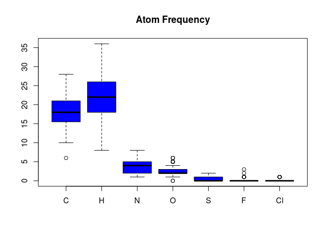

```r
 propma <- atomcountMA(sdfset, addH=FALSE)
 boxplot(propma, col="blue", main="Atom Frequency")
```

```r
 boxplot(rowSums(propma), main="All Atom Frequency")
```

Data frame provided by library containing atom names, atom symbols, standard atomic weights, group and period numbers:

```r
 data(atomprop)
 atomprop[1:4,]
```

```
##   Number      Name Symbol Atomic_weight Group Period
## 1      1  hydrogen      H      1.007940     1      1
## 2      2    helium     He      4.002602    18      1
## 3      3   lithium     Li      6.941000     1      2
## 4      4 beryllium     Be      9.012182     2      2
```

Compute MW and formula:

```r
 MW(sdfset[1:4], addH=FALSE)
```

```
##     CMP1     CMP2     CMP3     CMP4
## 456.4916 357.4069 370.4255 461.5346
```

```r
 MF(sdfset[1:4], addH=FALSE)
```

```
##          CMP1          CMP2          CMP3          CMP4
##  "C23H28N4O6"  "C18H23N5O3" "C18H18N4O3S" "C21H27N5O5S"
```

Enumerate functional groups:

```r
 groups(sdfset[1:4], groups="fctgroup", type="countMA")
```

```
##      RNH2 R2NH R3N ROPO3 ROH RCHO RCOR RCOOH RCOOR ROR RCCH RCN
## CMP1    0    2   1     0   0    0    0     0     0   2    0   0
## CMP2    0    2   2     0   1    0    0     0     0   0    0   0
## CMP3    0    1   1     0   1    0    1     0     0   0    0   0
## CMP4    0    1   3     0   0    0    0     0     0   2    0   0
```

Combine MW, MF, charges, atom counts, functional group counts and ring counts in one data frame:

```r
 propma <- data.frame(MF=MF(sdfset, addH=FALSE), MW=MW(sdfset, addH=FALSE),
                             Ncharges=sapply(bonds(sdfset, type="charge"), length),
                             atomcountMA(sdfset, addH=FALSE),
                             groups(sdfset, type="countMA"),
                             rings(sdfset, upper=6, type="count", arom=TRUE))
 propma[1:4,]
```

```
##               MF       MW Ncharges  C  H N O S F Cl RNH2 R2NH R3N ROPO3 ROH RCHO RCOR RCOOH RCOOR
## CMP1  C23H28N4O6 456.4916        0 23 28 4 6 0 0  0    0    2   1     0   0    0    0     0     0
## CMP2  C18H23N5O3 357.4069        0 18 23 5 3 0 0  0    0    2   2     0   1    0    0     0     0
## CMP3 C18H18N4O3S 370.4255        0 18 18 4 3 1 0  0    0    1   1     0   1    0    1     0     0
## CMP4 C21H27N5O5S 461.5346        0 21 27 5 5 1 0  0    0    1   3     0   0    0    0     0     0
##      ROR RCCH RCN RINGS AROMATIC
## CMP1   2    0   0     4        2
## CMP2   0    0   0     3        3
## CMP3   0    0   0     4        2
## CMP4   2    0   0     3        3
```

The following shows an example for assigning the values stored in a matrix (*e.g.* property descriptors) to the data block components in an `SDFset`. Each matrix row will be assigned to the corresponding slot position in the `SDFset`.

```r
 datablock(sdfset) <- propma # Works with all SDF components
 datablock(sdfset)[1:4]
 test <- apply(propma[1:4,], 1, function(x)
 data.frame(col=colnames(propma), value=x))
```

The data blocks in SDFs contain often important annotation information about compounds. The `datablock2ma` function returns this information as matrix for all compounds stored in an `SDFset` container. The `splitNumChar` function can then be used to organize all numeric columns in a `numeric matrix` and the character columns in a `character matrix` as components of a `list` object.

```r
 datablocktag(sdfset, tag="PUBCHEM_NIST_INCHI")
 datablocktag(sdfset,
 tag="PUBCHEM_OPENEYE_CAN_SMILES")
```

Convert entire data block to matrix:

```r
 blockmatrix <- datablock2ma(datablocklist=datablock(sdfset)) # Converts data block to matrix
 numchar <- splitNumChar(blockmatrix=blockmatrix) # Splits matrix to numeric matrix and character matrix
 numchar[[1]][1:4,]; numchar[[2]][1:4,]
 # Splits matrix to numeric matrix and character matrix
```

Back to Table of Contents

# 13 Bond Matrices

Bond matrices provide an efficient data structure for many basic computations on small molecules. The function `conMA` creates this data structure from `SDF` and `SDFset` objects. The resulting bond matrix contains the atom labels in the row/column titles and the bond types in the data part. The labels are defined as follows: 0 is no connection, 1 is a single bond, 2 is a double bond and 3 is a triple bond.

```r
 conMA(sdfset[1:2],
 exclude=c("H")) # Create bond matrix for first two molecules in sdfset

 conMA(sdfset[[1]], exclude=c("H")) # Return bond matrix for first molecule
 plot(sdfset[1], atomnum = TRUE, noHbonds=FALSE , no_print_atoms = "", atomcex=0.8) # Plot its structure with atom numbering
 rowSums(conMA(sdfset[[1]], exclude=c("H"))) # Return number of non-H bonds for each atom
```

Back to Table of Contents

# 14 Charges and Missing Hydrogens

The function `bonds` returns information about the number of bonds, charges and missing hydrogens in `SDF` and `SDFset` objects. It is used by many other functions (*e.g.* `MW`, `MF`, `atomcount`, `atomcuntMA` and `plot`) to correct for missing hydrogens that are often not specified in SD files.

```r
 bonds(sdfset[[1]], type="bonds")[1:4,]
```

```
##   atom Nbondcount Nbondrule charge
## 1    O          2         2      0
## 2    O          2         2      0
## 3    O          2         2      0
## 4    O          2         2      0
```

```r
 bonds(sdfset[1:2], type="charge")
```

```r
 bonds(sdfset[1:2], type="addNH")
```

```
## CMP1 CMP2
##    0    0
```

Back to Table of Contents

# 15 Ring Perception and Aromaticity Assignment

The function `rings` identifies all possible rings in one or many molecules (here `sdfset[1]`) using the exhaustive ring perception algorithm from Hanser et al. (1996). In addition, the function can return all smallest possible rings as well as aromaticity information.

The following example returns all possible rings in a `list`. The argument `upper` allows to specify an upper length limit for rings. Choosing smaller length limits will reduce the search space resulting in shortened compute times. Note: each ring is represented by a character vector of atom symbols that are numbered by their position in the atom block of the corresponding `SDF/SDFset` object.

```r
 ringatoms <- rings(sdfset[1], upper=Inf, type="all", arom=FALSE, inner=FALSE)
```

For visual inspection, the corresponding compound structure can be plotted with the ring bonds highlighted in color:

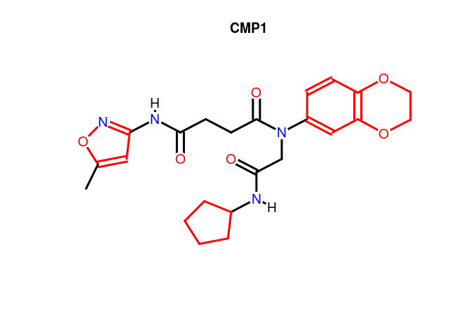

```r
 atomindex <- as.numeric(gsub(".*_", "", unique(unlist(ringatoms))))
 plot(sdfset[1], print=FALSE, colbonds=atomindex)
```

Alternatively, one can include the atom numbers in the plot:

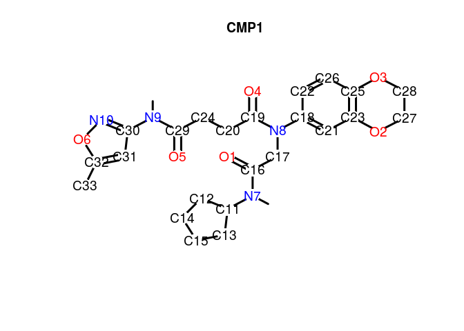

```r
 plot(sdfset[1], print=FALSE, atomnum=TRUE, no_print_atoms="H")
```

Aromaticity information of the rings can be returned in a logical vector by setting `arom=TRUE`:

```r
 rings(sdfset[1], upper=Inf, type="all", arom=TRUE, inner=FALSE)
```

```
## $RINGS
## $RINGS$ring1
## [1] "N_10" "O_6"  "C_32" "C_31" "C_30"
##
## $RINGS$ring2
## [1] "C_12" "C_14" "C_15" "C_13" "C_11"
##
## $RINGS$ring3
## [1] "C_23" "O_2"  "C_27" "C_28" "O_3"  "C_25"
##
## $RINGS$ring4
## [1] "C_23" "C_21" "C_18" "C_22" "C_26" "C_25"
##
## $RINGS$ring5
##  [1] "O_3"  "C_28" "C_27" "O_2"  "C_23" "C_21" "C_18" "C_22" "C_26" "C_25"
##
##
## $AROMATIC
## ring1 ring2 ring3 ring4 ring5
##  TRUE FALSE FALSE  TRUE FALSE
```

Return rings with no more than 6 atoms that are also aromatic:

```r
 rings(sdfset[1], upper=6, type="arom", arom=TRUE, inner=FALSE)
```

```
## $AROMATIC_RINGS
## $AROMATIC_RINGS$ring1
## [1] "N_10" "O_6"  "C_32" "C_31" "C_30"
##
## $AROMATIC_RINGS$ring4
## [1] "C_23" "C_21" "C_18" "C_22" "C_26" "C_25"
```

Count shortest possible rings and their aromaticity assignments by setting `type=count` and `inner=TRUE`. The inner (smallest possible) rings are identified by first computing all possible rings and then selecting only the inner rings. For more details, consult the help documentation with `?rings`.

```r
 rings(sdfset[1:4], upper=Inf, type="count", arom=TRUE, inner=TRUE)
```

```
##      RINGS AROMATIC
## CMP1     4        2
## CMP2     3        3
## CMP3     4        2
## CMP4     3        3
```

Back to Table of Contents

# 16 Rendering Chemical Structure Images

## 16.1 R Graphics Device

A new plotting function for compound structures has been added to the package recently. This function uses the native R graphics device for generating compound depictions. At this point this function is still in an experimental developmental stage but should become stable soon.

If you have `ChemmineOB` available you can use the `regenCoords` option to have OpenBabel regenerate the coordinates for the compound. This can sometimes produce better looking plots.

Plot compound Structures with R’s graphics device:

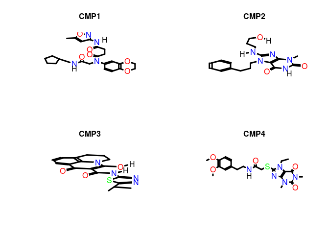

```r
 data(sdfsample)
 sdfset <- sdfsample
 plot(sdfset[1:4], regenCoords=TRUE,print=FALSE) # 'print=TRUE' returns SDF summaries
```

Customized plots:

```r
 plot(sdfset[1:4], griddim=c(2,2), print_cid=letters[1:4], print=FALSE,
        noHbonds=FALSE)
```

In the following plot, the atom block position numbers in the SDF are printed next to the atom symbols (`atomnum = TRUE`). For more details, consult help documentation with `?plotStruc` or `?plot`.

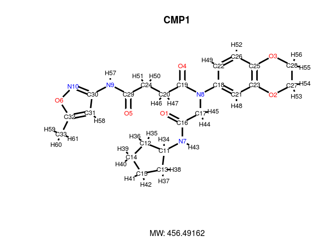

```r
 plot(sdfset["CMP1"], atomnum = TRUE, noHbonds=F , no_print_atoms = "",
        atomcex=0.8, sub=paste("MW:", MW(sdfsample["CMP1"])), print=FALSE)
```

Substructure highlighting by atom numbers:

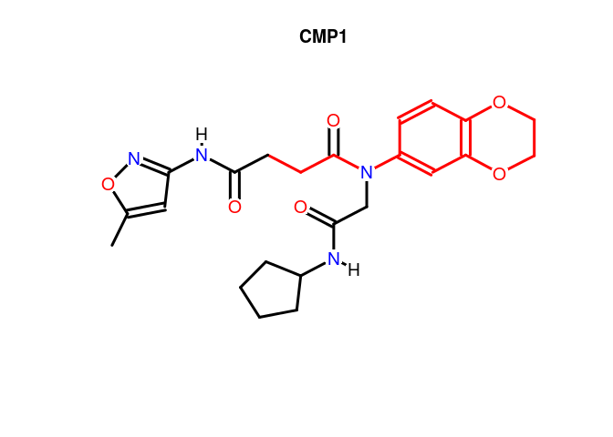

```r
 plot(sdfset[1], print=FALSE, colbonds=c(22,26,25,3,28,27,2,23,21,18,8,19,20,24))
```

Back to Table of Contents

## 16.2 Online with ChemMine Tools

Alternatively, one can visualize compound structures with a standard web browser using the online ChemMine Tools service.

Plot structures using web service ChemMine Tools:

```r
 sdf.visualize(sdfset[1:4])
```

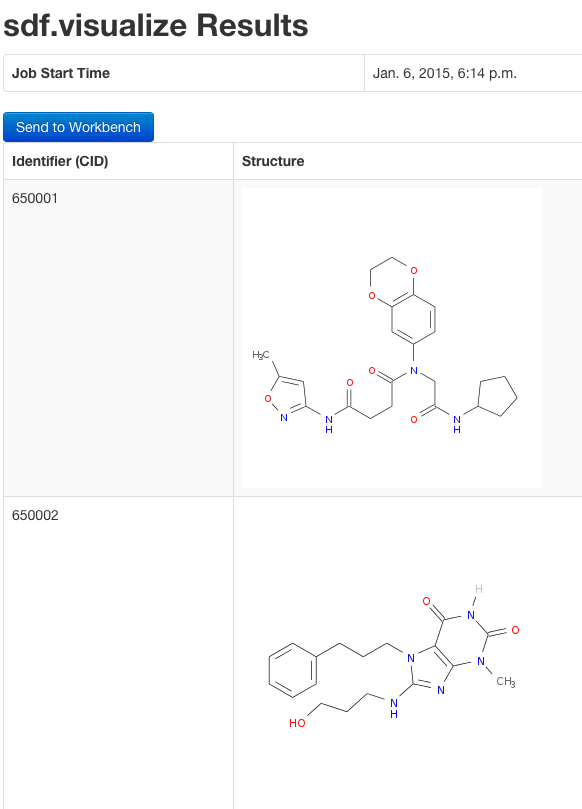

Figure: Visualization webpage created by calling `sdf.visualize`.

Back to Table of Contents

# 17 Similarity Comparisons and Searching

## 17.1 Maximum Common Substructure (MCS) Searching

The `ChemmineR` add-on package [`fmcsR`](http://www.bioconductor.org/packages/devel/bioc/html/fmcsR.html) provides support for identifying maximum common substructures (MCSs) and flexible MCSs among compounds. The algorithm can be used for pairwise compound comparisons, structure similarity searching and clustering. The manual describing this functionality is available [here](http://www.bioconductor.org/packages/devel/bioc/vignettes/fmcsR/inst/doc/fmcsR.html) and the associated publication is Wang et al. (2013). The following gives a short preview of some functionalities provided by the `fmcsR` package.

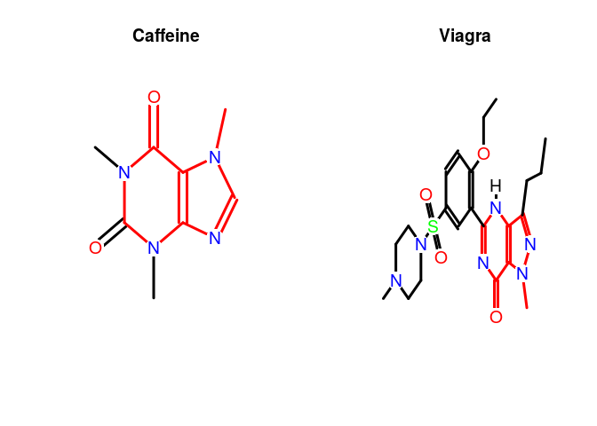

```r
 library(fmcsR)
 data(fmcstest) # Loads test sdfset object
 test <- fmcs(fmcstest[1], fmcstest[2], au=2, bu=1) # Searches for MCS with mismatches
 plotMCS(test) # Plots both query compounds with MCS in color
```

Back to Table of Contents

## 17.2 AP/APset Classes for Storing Atom Pair Descriptors

The function `sdf2ap` computes atom pair descriptors for one or many compounds (Carhart, Smith, and Venkataraghavan 1985; Chen and Reynolds 2002). It returns a searchable atom pair database stored in a container of class `APset`, which can be used for structural similarity searching and clustering. As similarity measure, the Tanimoto coefficient or related coefficients can be used. An `APset` object consists of one or many `AP` entries each storing the atom pairs of a single compound. Note: the deprecated `cmp.parse` function is still available which also generates atom pair descriptor databases, but directly from an SD file. Since the latter function is less flexible it may be discontinued in the future.

Generate atom pair descriptor database for searching:

```r
 ap <- sdf2ap(sdfset[[1]]) # For single compound
 ap
```

```
## An instance of "AP"
## <<atom pairs>>
## 52614450304 52615497856 52615514112 52616547456 52616554624 ... length: 528
```

```r
 apset <- sdf2ap(sdfset)
 # For many compounds.
```

```r
view(apset[1:4])
```

```
## $`650001`
## An instance of "AP"
## <<atom pairs>>
## 53688190976 53688190977 53688190978 53688190979 53688190980 ... length: 528
##
## $`650002`
## An instance of "AP"
## <<atom pairs>>
## 53688190976 53688190977 53688190978 53688190979 53689239552 ... length: 325
##
## $`650003`
## An instance of "AP"
## <<atom pairs>>
## 52615496704 53688190976 53688190977 53689239552 53697627136 ... length: 325
##
## $`650004`
## An instance of "AP"
## <<atom pairs>>
## 52617593856 52618642432 52619691008 52619691009 52628079616 ... length: 496
```

Return main components of APset objects:

```r
 cid(apset[1:4]) # Compound IDs
 ap(apset[1:4]) # Atom pair
 descriptors
 db.explain(apset[1]) # Return atom pairs in human readable format
```

Coerce APset to other objects:

```r
 apset2descdb(apset) # Returns old list-style AP database
 tmp <- as(apset, "list") # Returns list
 as(tmp, "APset") # Converts list back to APset
```

Back to Table of Contents

## 17.3 Large SDF and Atom Pair Databases

When working with large data sets it is often desirable to save the `SDFset` and `APset` containers as binary R objects to files for later use. This way they can be loaded very quickly into a new R session without recreating them every time from scratch.

Save and load of `SDFset` and `APset` containers:

```r
 save(sdfset, file = "sdfset.rda", compress = TRUE)
 load("sdfset.rda") save(apset, file = "apset.rda", compress = TRUE)
 load("apset.rda")
```

Back to Table of Contents

## 17.4 Pairwise Compound Comparisons with Atom Pairs

The `cmp.similarity` function computes the atom pair similarity between two compounds using the Tanimoto coefficient as similarity measure. The coefficient is defined as *c/(a+b+c)*, which is the proportion of the atom pairs shared among two compounds divided by their union. The variable *c* is the number of atom pairs common in both compounds, while *a* and *b* are the numbers of their unique atom pairs.

```r
 cmp.similarity(apset[1],
 apset[2])
```

```
## [1] 0.2637037
```

```r
 cmp.similarity(apset[1], apset[1])
```

```
## [1] 1
```

Back to Table of Contents

## 17.5 Similarity Searching with Atom Pairs

The `cmp.search` function searches an atom pair database for compounds that are similar to a query compound. The following example returns a data frame where the rows are sorted by the Tanimoto similarity score (best to worst). The first column contains the indices of the matching compounds in the database. The argument cutoff can be a similarity cutoff, meaning only compounds with a similarity value larger than this cutoff will be returned; or it can be an integer value restricting how many compounds will be returned. When supplying a cutoff of 0, the function will return the similarity values for every compound in the database.

```r
 cmp.search(apset,
 apset["650065"], type=3, cutoff = 0.3, quiet=TRUE)
```

```
##   index    cid    scores
## 1    61 650066 1.0000000
## 2    60 650065 1.0000000
## 3    67 650072 0.3389831
## 4    11 650011 0.3190608
## 5    15 650015 0.3184524
## 6    86 650092 0.3154270
## 7    64 650069 0.3010279
```

Alternatively, the function can return the matches in form of an index or a named vector if the `type` argument is set to `1` or `2`, respectively.

```r
 cmp.search(apset, apset["650065"], type=1, cutoff = 0.3, quiet=TRUE)
```

```
## [1] 61 60 67 11 15 86 64
```

```r
 cmp.search(apset, apset["650065"], type=2, cutoff = 0.3, quiet=TRUE)
```

```
##    650066    650065    650072    650011    650015    650092    650069
## 1.0000000 1.0000000 0.3389831 0.3190608 0.3184524 0.3154270 0.3010279
```

Back to Table of Contents

## 17.6 FP/FPset Classes for Storing Fingerprints

The `FPset` class stores fingerprints of small molecules in a matrix-like representation where every molecule is encoded as a fingerprint of the same type and length. The `FPset` container acts as a searchable database that contains the fingerprints of many molecules. The `FP` container holds only one fingerprint. Several constructor and coerce methods are provided to populate `FP/FPset` containers with fingerprints, while supporting any type and length of fingerprints. For instance, the function `desc2fp` generates fingerprints from an atom pair database stored in an `APset`, and `as(matrix, "FPset")` and `as(character, "FPset")` construct an `FPset` database from objects where the fingerprints are represented as `matrix` or `character` objects, respectively.

Show slots of `FPset` class:

```r
 showClass("FPset")
```

```
## Class "FPset" [package "ChemmineR"]
##
## Slots:
##
## Name:       fpma      type foldCount
## Class:    matrix character   numeric
```

Instance of `FPset` class:

```r
 data(apset)
 fpset <- desc2fp(apset)
 view(fpset[1:2])
```

```
## $`650001`
## An instance of "FP" of type "unknown-4721"
## <<fingerprint>>
## 1 1 1 1 1 1 1 1 1 1 1 1 1 1 1 1 1 1 1 1 ... length: 1024
##
## $`650002`
## An instance of "FP" of type "unknown-4173"
## <<fingerprint>>
## 1 1 1 1 1 1 1 1 1 1 0 1 1 1 1 0 0 0 1 1 ... length: 1024
```

`FPset` class usage:

```r
 fpset[1:4] # behaves like a list
```

```
## An instance of a 1024 bit "FPset" of type "apfp" with 4 molecules
```

```r
 fpset[[1]] # returns FP object
```

```
## An instance of "FP" of type "unknown-2986"
## <<fingerprint>>
## 1 1 1 1 1 1 1 1 1 1 1 1 1 1 1 1 1 1 1 1 ... length: 1024
```

```r
 length(fpset) # number of compounds ENDCOMMENT
```

```
## [1] 100
```

```r
 cid(fpset) # returns compound ids
```

```
##   [1] "650001" "650002" "650003" "650004" "650005" "650006" "650007" "650008" "650009" "650010"
##  [11] "650011" "650012" "650013" "650014" "650015" "650016" "650017" "650019" "650020" "650021"
##  [21] "650022" "650023" "650024" "650025" "650026" "650027" "650028" "650029" "650030" "650031"
##  [31] "650032" "650033" "650034" "650035" "650036" "650037" "650038" "650039" "650040" "650041"
##  [41] "650042" "650043" "650044" "650045" "650046" "650047" "650048" "650049" "650050" "650052"
##  [51] "650054" "650056" "650058" "650059" "650060" "650061" "650062" "650063" "650064" "650065"
##  [61] "650066" "650067" "650068" "650069" "650070" "650071" "650072" "650073" "650074" "650075"
##  [71] "650076" "650077" "650078" "650079" "650080" "650081" "650082" "650083" "650085" "650086"
##  [81] "650087" "650088" "650089" "650090" "650091" "650092" "650093" "650094" "650095" "650096"
##  [91] "650097" "650098" "650099" "650100" "650101" "650102" "650103" "650104" "650105" "650106"
```

```r
 fpset[10] <- 0 # replacement of 10th fingerprint to all zeros
 cid(fpset) <- 1:length(fpset) # replaces compound ids
 c(fpset[1:4], fpset[11:14]) # concatenation of several FPset objects
```

```
## An instance of a 1024 bit "FPset" of type "apfp" with 8 molecules
```

Construct `FPset` class form `matrix`:

```r
 fpma <- as.matrix(fpset) # coerces FPset to matrix
 as(fpma, "FPset")
```

```
## An instance of a 1024 bit "FPset" of type "unknown-6312" with 100 molecules
```

Construct `FPset` class form `character vector`:

```r
 fpchar <- as.character(fpset) # coerces FPset to character strings
 as(fpchar, "FPset") # construction of FPset class from character vector
```

```
## An instance of a 1024 bit "FPset" of type "apfp" with 100 molecules
```

Compound similarity searching with `FPset`:

```r
 fpSim(fpset[1], fpset, method="Tanimoto", cutoff=0.4, top=4)
```

```
##         1        96        67        15
## 1.0000000 0.4719101 0.4288499 0.4275229
```

Folding fingerprints:

```r
 fold(fpset) # fold each FP once
```

```
## An instance of a 512 bit "FPset" of type "apfp" with 100 molecules
```

```r
 fold(fpset, count=2) #fold each FP twice
```

```
## An instance of a 256 bit "FPset" of type "apfp" with 100 molecules
```

```r
 fold(fpset, bits=128) #fold each FP down to 128 bits
```

```
## An instance of a 128 bit "FPset" of type "apfp" with 100 molecules
```

```r
 fold(fpset[[1]])  # fold an individual FP
```

```
## An instance of "FP" of type "unknown-2996"
## <<fingerprint>>
## 1 1 1 1 1 1 1 1 1 1 1 1 1 1 1 1 1 1 1 1 ... length: 512
```

```r
 fptype(fpset) # get type of FPs
```

```
## [1] "apfp"
```

```r
 numBits(fpset) # get the number of bits of each FP
```

```
## [1] 1024
```

```r
 foldCount(fold(fpset)) # the number of times an FP or FPset has been folded
```

```
## [1] 1
```

Back to Table of Contents

## 17.7 Atom Pair Fingerprints

Atom pairs can be converted into binary atom pair fingerprints of fixed length. Computations on this compact data structure are more time and memory efficient than on their relatively complex atom pair counterparts. The function `desc2fp` generates fingerprints from descriptor vectors of variable length such as atom pairs stored in `APset` or `list` containers. The obtained fingerprints can be used for structure similarity comparisons, searching and clustering.

Create atom pair sample data set:

```r
 data(sdfsample)
 sdfset <- sdfsample[1:10]
 apset <- sdf2ap(sdfset)
```

Compute atom pair fingerprint database using internal atom pair selection containing the 4096 most common atom pairs identified in DrugBank’s compound collection. For details see `?apfp`. The following example uses from this set the 1024 most frequent atom pairs:

```r
 fpset <- desc2fp(apset, descnames=1024, type="FPset")
```

Alternatively, one can provide any custom atom pair selection. Here, the 1024 most common ones in `apset`:

```r
 fpset1024 <- names(rev(sort(table(unlist(as(apset, "list")))))[1:1024])
 fpset <- desc2fp(apset, descnames=fpset1024, type="FPset")
```

A more compact way of storing fingerprints is as character values:

```r
 fpchar <- desc2fp(x=apset,
 descnames=1024, type="character") fpchar <- as.character(fpset)
```

Converting a fingerprint database to a matrix and vice versa:

```r
 fpma <- as.matrix(fpset)
 fpset <- as(fpma, "FPset")
```

Similarity searching and returning Tanimoto similarity coefficients:

```r
 fpSim(fpset[1], fpset, method="Tanimoto")
```

Under `method` one can choose from several predefined similarity measures including *Tanimoto* (default), *Euclidean*, *Tversky* or *Dice*. Alternatively, one can pass on custom similarity functions.

```r
 fpSim(fpset[1], fpset, method="Tversky", cutoff=0.4, top=4, alpha=0.5, beta=1)
```

Example for using a custom similarity function:

```r
 myfct <- function(a, b, c, d) c/(a+b+c+d)
 fpSim(fpset[1], fpset, method=myfct)
```

Clustering example:

```r
 simMAap <- sapply(cid(apfpset), function(x) fpSim(x=apfpset[x], apfpset, sorted=FALSE))
 hc <- hclust(as.dist(1-simMAap), method="single")
 plot(as.dendrogram(hc), edgePar=list(col=4, lwd=2), horiz=TRUE)
```

Back to Table of Contents

## 17.8 Fingerprint E-values

The `fpSim` function can also return Z-scores, E-values, and p-values if given a set of score distribution parameters. These parameters can be computed over an `fpSet` with the `genParameters` function.

```r
    params <- genParameters(fpset)
```

This function will compute all pairwise distances between the given fingerprints and then fit a Beta distribution to the resulting Tanimoto scores, conditioned on the number of set bits in each fingerprint. For large data sets where you would not want to compute all pairwise distances, you can set what fraction to sample with the `sampleFraction` argument. This step only needs to be done once for each database of `fpSet` objects. Alternatively, if you have a large database of fingerprints, or you believe that the parameters computed on a single database are more generally applicable, you can use the resulting parameters for other databases as well.

Once you have a set of parameters, you can pass them to `fpSim` with the `parameters` argument.

```r
    fpSim(fpset[[1]], fpset, top=10, parameters=params)
```

```
##    similarity    zscore    evalue    pvalue
## 1   1.0000000 6.2418215  0.000000 0.0000000
## 96  0.4719101 1.6075792  6.748413 0.9988273
## 67  0.4288499 1.2297052 12.012285 0.9999939
## 15  0.4275229 1.2180604 12.211967 0.9999950
## 88  0.4247423 1.1936587 12.638193 0.9999968
## 64  0.4187380 1.1409688 13.594938 0.9999988
## 4   0.4166667 1.1227914 13.936692 0.9999991
## 86  0.3978686 0.9578290 17.319191 1.0000000
## 77  0.3970588 0.9507232 17.476453 1.0000000
## 69  0.3940000 0.9238806 18.079243 1.0000000
```

This will then return a data frame with the similarity, Z-score, E-value, and p-value. You can change which value will be used as a cutoff and to sort by by setting the argument `scoreType` to one of these scores. In this way you could set an E-value cutoff of 0.04 for example.

```r
    fpSim(fpset[[1]], fpset, cutoff=0.04, scoreType="evalue", parameters=params)
```

```
##   similarity   zscore evalue pvalue
## 1          1 6.241822      0      0
```

Back to Table of Contents

## 17.9 Pairwise Compound Comparisons with PubChem Fingerprints

The `fpSim` function computes the similarity coefficients (*e.g.* Tanimoto) for pairwise comparisons of binary fingerprints. For this data type, *c* is the number of “on-bits” common in both compounds, and *a* and *b* are the numbers of their unique “on-bits”. Currently, the PubChem fingerprints need to be provided (here PubChem’s SD files) and cannot be computed from scratch in `ChemmineR`. The PubChem fingerprint specifications can be loaded with `data(pubchemFPencoding)`.

Convert base 64 encoded PubChem fingerprints to `character` vector, `matrix` or `FPset` object:

```r
 cid(sdfset) <- sdfid(sdfset)
 fpset <- fp2bit(sdfset, type=1)
 fpset <- fp2bit(sdfset, type=2)
 fpset <- fp2bit(sdfset, type=3)
 fpset
```

```
## An instance of a 881 bit "FPset" of type "pubchem" with 100 molecules
```

Pairwise compound structure comparisons:

```r
 fpSim(fpset[1], fpset[2])
```

```
##    650002
## 0.5364807
```

Back to Table of Contents

## 17.10 Similarity Searching with PubChem Fingerprints

Similarly, the `fpSim` function provides search functionality for PubChem fingerprints:

```r
 fpSim(fpset["650065"], fpset, method="Tanimoto", cutoff=0.6, top=6)
```

```
##    650065    650066    650035    650019    650012    650046
## 1.0000000 0.9944751 0.7435897 0.7432432 0.7230047 0.7142857
```

Back to Table of Contents

## 17.11 Visualize Similarity Search Results

The `cmp.search` function allows to visualize the chemical structures for the search results. Similar but more flexible chemical structure rendering functions are `plot` and `sdf.visualize` described above. By setting the visualize argument in `cmp.search` to `TRUE`, the matching compounds and their scores can be visualized with a standard web browser. Depending on the `visualize.browse` argument, an URL will be printed or a webpage will be opened showing the structures of the matching compounds.

View similarity search results in R’s graphics device:

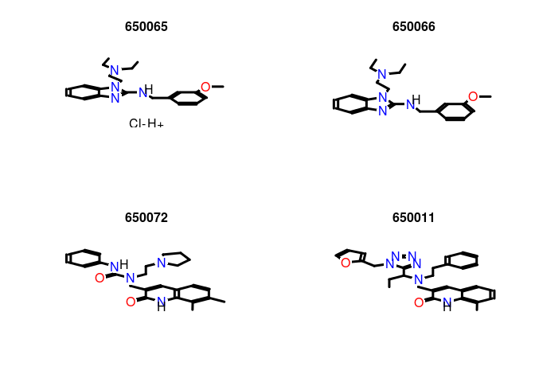

```r
 cid(sdfset) <-
 cid(apset) # Assure compound name consistency among objects.

 plot(sdfset[names(cmp.search(apset, apset["650065"], type=2, cutoff=4, quiet=TRUE))], print=FALSE)
```

View results online with Chemmine Tools:

```r
 similarities <- cmp.search(apset, apset[1], type=3, cutoff = 10)
 sdf.visualize(sdfset[similarities[,1]])
```

Back to Table of Contents

# 18 Clustering

## 18.1 Clustering Identical or Very Similar Compounds

Often it is of interest to identify very similar or identical compounds in a compound set. The `cmp.duplicated` function can be used to quickly identify very similar compounds in atom pair sets, which will be frequently, but not necessarily, identical compounds.

Identify compounds with identical AP sets:

```r
 cmp.duplicated(apset, type=1)[1:4] # Returns AP duplicates as logical vector
```

```
## [1] FALSE FALSE FALSE FALSE
```

```r
 cmp.duplicated(apset, type=2)[1:4,] # Returns AP duplicates as data frame
```

```
##      ids CLSZ_100 CLID_100
## 1 650082        1        1
## 2 650059        2        2
## 3 650060        2        2
## 4 650010        1        3
```

Plot the structure of two pairs of duplicates:

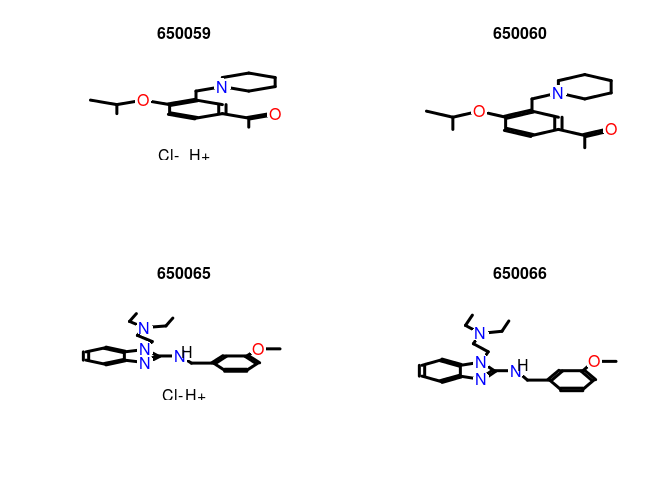

```r
 plot(sdfset[c("650059","650060", "650065", "650066")], print=FALSE)
```

Remove AP duplicates from SDFset and APset objects:

```r
 apdups <- cmp.duplicated(apset, type=1)
 sdfset[which(!apdups)]; apset[which(!apdups)]
```

```
## An instance of "SDFset" with 96 molecules
```

```
## An instance of "APset" with 96 molecules
```

Alternatively, one can identify duplicates via other descriptor types if they are provided in the data block of an imported SD file. For instance, one can use here fingerprints, InChI, SMILES or other molecular representations. The following examples show how to enumerate by identical InChI strings, SMILES strings and molecular formula, respectively.

```r
 count <- table(datablocktag(sdfset,
 tag="PUBCHEM_NIST_INCHI"))
 count <- table(datablocktag(sdfset, tag="PUBCHEM_OPENEYE_CAN_SMILES"))
 count <- table(datablocktag(sdfset, tag="PUBCHEM_MOLECULAR_FORMULA"))
 count[1:4]
```

```
##
##  C10H9FN2O2S   C11H12N4OS    C11H13NO4 C12H11ClN2OS
##            1            1            1            1
```

Back to Table of Contents

## 18.2 Binning Clustering

Compound libraries can be clustered into discrete similarity groups with the binning clustering function `cmp.cluster`. The function accepts as input an atom pair (`APset`) or a fingerprint (`FPset`) descriptor database as well as a similarity threshold. The binning clustering result is returned in form of a data frame. Single linkage is used for cluster joining. The function calculates the required compound-to-compound distance information on the fly, while a memory-intensive distance matrix is only created upon user request via the `save.distances` argument (see below).

Because an optimum similarity threshold is often not known, the `cmp.cluster` function can calculate cluster results for multiple cutoffs in one step with almost the same speed as for a single cutoff. This can be achieved by providing several cutoffs under the cutoff argument. The clustering results for the different cutoffs will be stored in one data frame.

One may force the `cmp.cluster` function to calculate and store the distance matrix by supplying a file name to the `save.distances` argument. The generated distance matrix can be loaded and passed on to many other clustering methods available in R, such as the hierarchical clustering function `hclust` (see below).

If a distance matrix is available, it may also be supplied to `cmp.cluster` via the `use.distances` argument. This is useful when one has a pre-computed distance matrix either from a previous call to `cmp.cluster` or from other distance calculation subroutines.

Single-linkage binning clustering with one or multiple cutoffs:

```r
 clusters <- cmp.cluster(db=apset, cutoff = c(0.7, 0.8, 0.9), quiet = TRUE)
```

```
##
## sorting result...
```

```r
 clusters[1:12,]
```

```
##       ids CLSZ_0.7 CLID_0.7 CLSZ_0.8 CLID_0.8 CLSZ_0.9 CLID_0.9
## 48 650049        2       48        2       48        2       48
## 49 650050        2       48        2       48        2       48
## 54 650059        2       54        2       54        2       54
## 55 650060        2       54        2       54        2       54
## 56 650061        2       56        2       56        2       56
## 57 650062        2       56        2       56        2       56
## 58 650063        2       58        2       58        2       58
## 59 650064        2       58        2       58        2       58
## 60 650065        2       60        2       60        2       60
## 61 650066        2       60        2       60        2       60
## 1  650001        1        1        1        1        1        1
## 2  650002        1        2        1        2        1        2
```

Clustering of `FPset` objects with multiple cutoffs. This method allows to call various similarity methods provided by the `fpSim` function. For details consult `?fpSim`.

```r
 fpset <- desc2fp(apset)
 clusters2 <- cmp.cluster(fpset, cutoff=c(0.5, 0.7, 0.9), method="Tanimoto", quiet=TRUE)
```

```
##
## sorting result...
```

```r
 clusters2[1:12,]
```

```
##       ids CLSZ_0.5 CLID_0.5 CLSZ_0.7 CLID_0.7 CLSZ_0.9 CLID_0.9
## 69 650074       14       11        2       69        1       69
## 79 650085       14       11        2       69        1       79
## 11 650011       14       11        1       11        1       11
## 15 650015       14       11        1       15        1       15
## 45 650046       14       11        1       45        1       45
## 47 650048       14       11        1       47        1       47
## 51 650054       14       11        1       51        1       51
## 53 650058       14       11        1       53        1       53
## 64 650069       14       11        1       64        1       64
## 65 650070       14       11        1       65        1       65
## 67 650072       14       11        1       67        1       67
## 86 650092       14       11        1       86        1       86
```

Sames as above, but using Tversky similarity measure:

```r
 clusters3 <- cmp.cluster(fpset, cutoff=c(0.5, 0.7, 0.9),
                                  method="Tversky", alpha=0.3, beta=0.7, quiet=TRUE)
```

```
##
## sorting result...
```

Return cluster size distributions for each cutoff:

```r
 cluster.sizestat(clusters, cluster.result=1)
```

```
##   cluster size count
## 1            1    90
## 2            2     5
```

```r
 cluster.sizestat(clusters, cluster.result=2)
```

```
##   cluster size count
## 1            1    90
## 2            2     5
```

```r
 cluster.sizestat(clusters, cluster.result=3)
```

```
##   cluster size count
## 1            1    90
## 2            2     5
```

Enforce calculation of distance matrix:

```r
 clusters <- cmp.cluster(db=apset, cutoff = c(0.65, 0.5, 0.3),
 save.distances="distmat.rda") # Saves distance matrix to file "distmat.rda" in current working directory.
 load("distmat.rda") # Loads distance matrix.
```

Back to Table of Contents

## 18.3 Jarvis-Patrick Clustering

The Jarvis-Patrick clustering algorithm is widely used in cheminformatics (Jarvis and Patrick 1973). It requires a nearest neighbor table, which consists of *j* nearest neighbors for each item (*e.g.* compound). The nearest neighbor table is then used to join items into clusters when they meet the following requirements: (a) they are contained in each other’s neighbor list and (b) they share at least *k* nearest neighbors. The values for *j* and *k* are user-defined parameters. The `jarvisPatrick` function implemented in `ChemmineR` takes a nearest neighbor table generated by `nearestNeighbors`, which works for `APset` and `FPset` objects. This function takes either the standard Jarvis-Patrick *j* parameter (as the `numNbrs` parameter), or else a `cutoff` value, which is an extension to the basic algorithm that we have added. Given a cutoff value, the nearest neighbor table returned contains every neighbor with a similarity greater than the cutoff value, for each item. This allows one to generate tighter clusters and to minimize certain limitations of this method, such as false joins of completely unrelated items when operating on small data sets. The `trimNeighbors` function can also be used to take an existing nearest neighbor table and remove all neighbors whose similarity value is below a given cutoff value. This allows one to compute a very relaxed nearest neighbor table initially, and then quickly try different refinements later.

In case an existing nearest neighbor matrix needs to be used, the `fromNNMatrix` function can be used to transform it into the list structure that `jarvisPatrick` requires. The input matrix must have a row for each compound, and each row should be the index values of the neighbors of compound represented by that row. The names of each compound can also be given through the `names` argument. If not given, it will attempt to use the `rownames` of the given matrix.

The `jarvisPatrick` function also allows one to relax some of the requirements of the algorithm through the `mode` parameter. When set to “a1a2b”, then all requirements are used. If set to “a1b”, then (a) is relaxed to a unidirectional requirement. Lastly, if `mode` is set to “b”, then only requirement (b) is used, which means that all pairs of items will be checked to see if (b) is satisfied between them. The size of the clusters generated by the different methods increases in this order: “a1a2b” < “a1b” < “b”. The run time of method “a1a2b” follows a close to linear relationship, while it is nearly quadratic for the much more exhaustive method “b”. Only methods “a1a2b” and “a1b” are suitable for clustering very large data sets (e.g. >50,000 items) in a reasonable amount of time.

An additional extension to the algorithm is the ability to set the linkage mode. The `linkage` parameter can be one of “single”, “average”, or “complete”, for single linkage, average linkage and complete linkage merge requirements, respectively. In the context of Jarvis-Patrick, average linkage means that at least half of the pairs between the clusters under consideration must meet requirement (b). Similarly, for complete linkage, all pairs must requirement (b). Single linkage is the normal case for Jarvis-Patrick and just means that at least one pair must meet requirement (b).

The output is a cluster `vector` with the item labels in the name slot and the cluster IDs in the data slot. There is a utility function called `byCluster`, which takes out cluster vector output by `jarvisPatrick` and transforms it into a list of vectors. Each slot of the list is named with a cluster id and the vector contains the cluster members. By default the function excludes singletons from the output, but they can be included by setting `excludeSingletons`=FALSE`.

Load/create sample `APset` and `FPset`:

```r
 data(apset)
 fpset <- desc2fp(apset)
```

Standard Jarvis-Patrick clustering on `APset` and `FPset` objects:

```r
 jarvisPatrick(nearestNeighbors(apset,numNbrs=6), k=5, mode="a1a2b")
```

```
## 650001 650002 650003 650004 650005 650006 650007 650008 650009 650010 650011 650012 650013 650014
##      1      2      3      4      5      6      7      8      9     10     11     12     13     14
## 650015 650016 650017 650019 650020 650021 650022 650023 650024 650025 650026 650027 650028 650029
##     11     15     16     17     18     19     20     21     22     23     24     25     26     27
## 650030 650031 650032 650033 650034 650035 650036 650037 650038 650039 650040 650041 650042 650043
##     28     29     30     31     32     33     34     35     36     37     38     39     40     41
## 650044 650045 650046 650047 650048 650049 650050 650052 650054 650056 650058 650059 650060 650061
##     42     43     44     45     46     47     48     49     50     51     52     53     54     55
## 650062 650063 650064 650065 650066 650067 650068 650069 650070 650071 650072 650073 650074 650075
##     56     57     58     59     60     61     62     63     64     65     66     67     68     69
## 650076 650077 650078 650079 650080 650081 650082 650083 650085 650086 650087 650088 650089 650090
##     70     71     72     73     74     75     76     77     78     79     80     81     82     83
## 650091 650092 650093 650094 650095 650096 650097 650098 650099 650100 650101 650102 650103 650104
##     84     85     86     87     88     89     90     91     92     93     94     95     96     97
## 650105 650106
##     98     99
```

```r
 #Using "APset"

 jarvisPatrick(nearestNeighbors(fpset,numNbrs=6), k=5, mode="a1a2b")
```

```
## 650001 650002 650003 650004 650005 650006 650007 650008 650009 650010 650011 650012 650013 650014
##      1      2      3      4      5      6      7      8      9     10     11     12     13     14
## 650015 650016 650017 650019 650020 650021 650022 650023 650024 650025 650026 650027 650028 650029
##     11     15     16     17     18     19     20     21     22     23     24     25     26     27
## 650030 650031 650032 650033 650034 650035 650036 650037 650038 650039 650040 650041 650042 650043
##     28     29     30     31     32     33     34     35     36     37     38     39     40     41
## 650044 650045 650046 650047 650048 650049 650050 650052 650054 650056 650058 650059 650060 650061
##     42     43     44     45     46     47     48     49     50     51     52     53     54     55
## 650062 650063 650064 650065 650066 650067 650068 650069 650070 650071 650072 650073 650074 650075
##     56     57     58     59     60     61     62     63     64     65     66     67     68     69
## 650076 650077 650078 650079 650080 650081 650082 650083 650085 650086 650087 650088 650089 650090
##     70     71     72     73     74     75     76     77     78     79     80     81     82     83
## 650091 650092 650093 650094 650095 650096 650097 650098 650099 650100 650101 650102 650103 650104
##     84     85     86     87     88     89     90     91     92     93     94      1     95     96
## 650105 650106
##     97     98
```

```r
 #Using "FPset"
```

The following example runs Jarvis-Patrick clustering with a minimum similarity `cutoff` value (here Tanimoto coefficient). In addition, it uses the much more exhaustive `"b"` method that generates larger cluster sizes, but significantly increased the run time. For more details, consult the corresponding help file with `?jarvisPatrick`.

```r
 cl<-jarvisPatrick(nearestNeighbors(fpset,cutoff=0.6,
 method="Tanimoto"), k=2 ,mode="b")
 byCluster(cl)
```

```
## $`11`
## [1] "650011" "650092"
##
## $`15`
## [1] "650015" "650069"
##
## $`45`
## [1] "650046" "650054"
##
## $`48`
## [1] "650049" "650050"
##
## $`52`
## [1] "650059" "650060"
##
## $`53`
## [1] "650061" "650062"
##
## $`54`
## [1] "650063" "650064"
##
## $`55`
## [1] "650065" "650066"
##
## $`62`
## [1] "650074" "650085"
```

Output nearest neighbor table (`matrix`):

```r
 nnm <- nearestNeighbors(fpset,numNbrs=6)
 nnm$names[1:4]
```

```
## [1] "650001" "650002" "650003" "650004"
```

```r
 nnm$ids[1:4,]
```

[output not shown]

```r
 nnm$similarities[1:4,]
```

```
##     650001    650102    650072    650015    650094    650069
## sim      1 0.4719101 0.4288499 0.4275229 0.4247423 0.4187380
## sim      1 0.4343891 0.4246575 0.4216867 0.3939394 0.3922078
## sim      1 0.4152249 0.3619303 0.3610315 0.3424242 0.3367089
## sim      1 0.5791045 0.4973958 0.4192708 0.4166667 0.4104683
```

Trim nearest neighbor table:

```r
 nnm <- trimNeighbors(nnm,cutoff=0.4)
 nnm$similarities[1:4,]
```

```
##     650001    650102    650072    650015    650094    650069
## sim      1 0.4719101 0.4288499 0.4275229 0.4247423 0.4187380
## sim      1 0.4343891 0.4246575 0.4216867        NA        NA
## sim      1 0.4152249        NA        NA        NA        NA
## sim      1 0.5791045 0.4973958 0.4192708 0.4166667 0.4104683
```

Perform clustering on precomputed nearest neighbor table:

```r
 jarvisPatrick(nnm, k=5,mode="b")
```

```
## 650001 650002 650003 650004 650005 650006 650007 650008 650009 650010 650011 650012 650013 650014
##      1      2      3      4      5      6      7      8      9     10     11     12     13     14
## 650015 650016 650017 650019 650020 650021 650022 650023 650024 650025 650026 650027 650028 650029
##     11     15     16     17     18     19     20     21     22     23     24     25     26     27
## 650030 650031 650032 650033 650034 650035 650036 650037 650038 650039 650040 650041 650042 650043
##     28     29     30     31     32     33     34     35     36     37     38     39     40     41
## 650044 650045 650046 650047 650048 650049 650050 650052 650054 650056 650058 650059 650060 650061
##     42     43     11     44     11     45     46     47     48     49     50     51     52     53
## 650062 650063 650064 650065 650066 650067 650068 650069 650070 650071 650072 650073 650074 650075
##     54     55     56     57     57     58     59     11     60     61     62     63     64     65
## 650076 650077 650078 650079 650080 650081 650082 650083 650085 650086 650087 650088 650089 650090
##     66     67     68     69     37     70     71     72     64     73     74     75     76     77
## 650091 650092 650093 650094 650095 650096 650097 650098 650099 650100 650101 650102 650103 650104
##     78     11     79     80     81     82     83     84     85     86     87      1     88     89
## 650105 650106
##     90     91
```

Using a user defined nearest neighbor matrix:

```r
 nn <- matrix(c(1,2,2,1),2,2,dimnames=list(c('one','two')))
 nn
```

```
##     [,1] [,2]
## one    1    2
## two    2    1
```

```r
 byCluster(jarvisPatrick(fromNNMatrix(nn),k=1))
```

```
## $`1`
## [1] "one" "two"
```

Back to Table of Contents

## 18.4 Multi-Dimensional Scaling (MDS)

To visualize and compare clustering results, the `cluster.visualize` function can be used. The function performs Multi-Dimensional Scaling (MDS) and visualizes the results in form of a scatter plot. It requires as input an `APset`, a clustering result from `cmp.cluster`, and a cutoff for the minimum cluster size to consider in the plot. To help determining a proper cutoff size, the `cluster.sizestat` function is provided to generate cluster size statistics.

MDS clustering and scatter plot:

```r
 cluster.visualize(apset, clusters, size.cutoff=2, quiet = TRUE) # Color codes clusters with at least two members.
 cluster.visualize(apset, clusters, quiet = TRUE) # Plots all items.
```

Create a 3D scatter plot of MDS result:

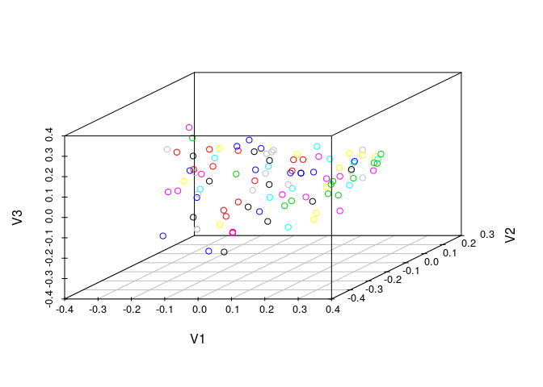

```r
 library(scatterplot3d)
 coord <- cluster.visualize(apset, clusters, size.cutoff=1, dimensions=3, quiet=TRUE)
 scatterplot3d(coord)
```

Interactive 3D scatter plot with Open GL (graphics not evaluated here):

```r
 library(rgl) rgl.open(); offset <- 50;
 par3d(windowRect=c(offset, offset, 640+offset, 640+offset))
 rm(offset)
 rgl.clear()
 rgl.viewpoint(theta=45, phi=30, fov=60, zoom=1)
 spheres3d(coord[,1], coord[,2], coord[,3], radius=0.03, color=coord[,4], alpha=1, shininess=20)
 aspect3d(1, 1, 1)
 axes3d(col='black')
 title3d("", "", "", "", "", col='black')
 bg3d("white") # To save a snapshot of the graph, one can use the command rgl.snapshot("test.png").
```

Back to Table of Contents

## 18.5 Clustering with Other Algorithms

`ChemmineR` allows the user to take advantage of the wide spectrum of clustering utilities available in R. An example on how to perform hierarchical clustering with the hclust function is given below.

Create atom pair distance matrix:

```r
 dummy <- cmp.cluster(db=apset, cutoff=0, save.distances="distmat.rda", quiet=TRUE)
```

```
##
## sorting result...
```

```r
 load("distmat.rda")
```

Hierarchical clustering with `hclust`:

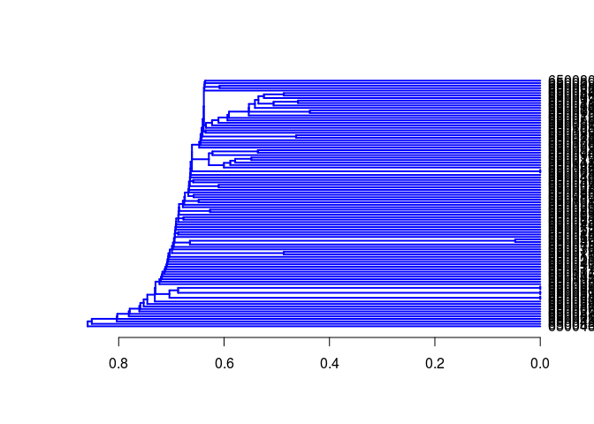

```r
 hc <- hclust(as.dist(distmat), method="single")
 hc[["labels"]] <- cid(apset) # Assign correct item labels
 plot(as.dendrogram(hc), edgePar=list(col=4, lwd=2), horiz=T)
```

Instead of atom pairs one can use PubChem’s fingerprints for clustering:

```r
 simMA <- sapply(cid(fpset), function(x) fpSim(fpset[x], fpset, sorted=FALSE))
 hc <- hclust(as.dist(1-simMA), method="single")
 plot(as.dendrogram(hc), edgePar=list(col=4, lwd=2), horiz=TRUE)
```

Plot dendrogram with heatmap (here similarity matrix):

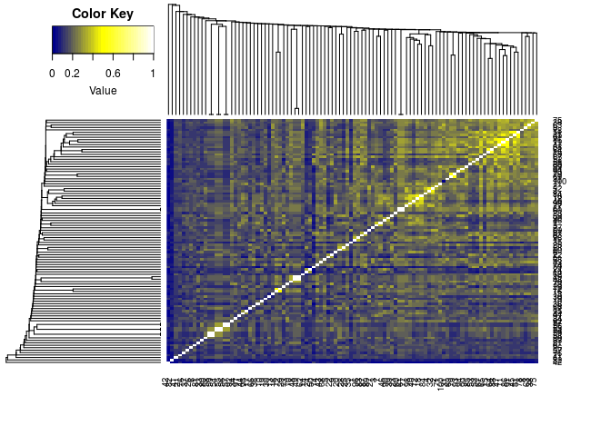

```r
 library(gplots)
 heatmap.2(1-distmat, Rowv=as.dendrogram(hc), Colv=as.dendrogram(hc),
              col=colorpanel(40, "darkblue", "yellow", "white"),
              density.info="none", trace="none")
```

Back to Table of Contents

# 19 Searching PubChem

## 19.1 Get Compounds from PubChem by Id

The function `getIds` accepts one or more numeric PubChem compound ids and downloads the corresponding compounds from PubChem Power User Gateway (PUG) returning results in an `SDFset` container. The ChemMine Tools web service is used as an intermediate, to translate queries from plain HTTP POST to a PUG SOAP query.

Fetch 2 compounds from PubChem:

```r
 compounds <- getIds(c(111,123))
 compounds
```

Back to Table of Contents

## 19.2 Search a SMILES Query in PubChem

The function `searchString` accepts one SMILES string (Simplified Molecular Input Line Entry Specification) and performs a >0.95 similarity PubChem fingerprint search, returning the hits in an `SDFset` container. The ChemMine Tools web service is used as an intermediate, to translate queries from plain HTTP POST to a PubChem Power User Gateway (PUG) query.

Search a SMILES string on PubChem:

```r
 compounds <- searchString("CC(=O)OC1=CC=CC=C1C(=O)O") compounds
```

Back to Table of Contents

## 19.3 Search an SDF Query in PubChem

The function `searchSim` performs a PubChem similarity search just like `searchString`, but accepts a query in an `SDFset` container. If the query contains more than one compound, only the first is searched.

Search an `SDFset` container on PubChem:

```r
 data(sdfsample);
 sdfset <- sdfsample[1]
 compounds <- searchSim(sdfset)
 compounds
```

Back to Table of Contents

# 20 ChemMine Tools R Interface

ChemMine Web Tools is an online service for analyzing and clustering small molecules. It provides numerous cheminformatics tools which can be used directly on the website, or called remotely from within R. When called within R jobs are sent remotely to a queue on a compute cluster at UC Riverside, which is a free service offered to `ChemmineR` users. The website is free and open to all users and is available at http://chemmine.ucr.edu. When new tools are added to the service, they automatically become availiable within `ChemmineR` without updating your local R package.

List all available tools:

```r
listCMTools()
```

```
##      Category                           Name      Input     Output
## 1      Upload                Upload CSV Data  character data.frame
## 2      Upload      Upload Tab Delimited Data  character data.frame
## 3  Properties             JoeLib Descriptors     SDFset data.frame
## 4  Properties          OpenBabel Descriptors     SDFset data.frame
## 5  Clustering             Binning Clustering     SDFset  character
## 6  Clustering Multidimensional Scaling (MDS)     SDFset  character
## 7  Clustering        Numeric Data Clustering     SDFset  character
## 8  Clustering        Hierarchical Clustering     SDFset  character
## 9      Search                  pubchemID2SDF data.frame     SDFset
## 10   Plotting               Graph Visualizer     igraph  character
## 11 Properties           ChemmineR Properties     SDFset data.frame
## 12  ChemmineR                  sdf.visualize     SDFset     SDFset
## 13     Search                      EI Search     SDFset    integer
## 14     Search             Fingerprint Search     SDFset    integer
```

Show options and description for a tool. This also provides an example function call which can be copied verbatim, and changed as necessary:

```r
toolDetails("Fingerprint Search")
```

```
## Category:        Search
## Name:            Fingerprint Search
## Input R Object:      SDFset
## Input mime type: chemical/x-mdl-sdfile
## Output R Object: integer
## Output mime type:    text/fp.search.result
## ###### BEGIN DESCRIPTION ######
## PubChem Fingerprint Search
## ####### END DESCRIPTION #######
## Option 1: 'Similarity Cutoff'
## Allowed Values:  '0.5' '0.6' '0.7' '0.8' '0.85' '0.9' '0.91' '0.92' '0.93' '0.94' '0.95' '0.96' '0.97' '0.98' '0.99'
## Option 2: 'Max Compounds Returned'
## Allowed Values:  '10' '50' '100' '200' '1000'
## Example function call:
##  job <- launchCMTool(
##      'Fingerprint Search',
##      SDFset,
##      'Similarity Cutoff'='0.5',
##      'Max Compounds Returned'='10'
##  )
```

Back to Table of Contents

## 20.1 Launch a Job

When a job is launched it returns a job token which refers to the running job on the UC Riverside cluster. You can check the status of a job or obtain the results as follows. If `result` is called on a job that is still running, it will loop internally until the job is completed, and then return the result.

Launch the tool `pubchemID2SDF` to obtain the structure for PubChem cid 2244:

```r
job1 <- launchCMTool("pubchemID2SDF", 2244)
status(job1)
result1 <- result(job1)
```

Use the previous result to search PubChem for similar compounds:

```r
job2 <- launchCMTool('Fingerprint Search', result1, 'Similarity Cutoff'=0.95, 'Max Compounds Returned'=200)
result2 <- result(job2)
job3 <- launchCMTool("pubchemID2SDF", result2)
result3 <- result(job3)
```

Compute OpenBabel descriptors for these search results:

```r
job4 <- launchCMTool("OpenBabel Descriptors", result3)
result4 <- result(job4)
result4[1:10,] # show first 10 lines of result
```

```
##         cid abonds atoms bonds dbonds HBA1 HBA2 HBD   logP      MR       MW nF sbonds tbonds  TPSA
## 1      2244      6    21    21      2   12    4   1 1.3101 44.9003 180.1574  0     13      0 63.60
## 2      5161     12    29    30      2   15    5   2 2.3096 66.8248 258.2262  0     16      0 83.83
## 3     68484      6    24    24      2   14    4   0 1.3985 49.2205 194.1840  0     16      0 52.60
## 4     10745     12    34    35      3   18    6   1 2.5293 76.3008 300.2629  0     20      0 89.90
## 5    135269      6    30    30      2   18    4   1 2.4804 59.3213 222.2372  0     22      0 63.60
## 6     67252      6    22    22      1   13    3   1 1.7835 44.7003 166.1739  0     15      0 46.53
## 7    171511      6    25    23      2   16    5   2 1.2458 47.9481 222.4777  0     15      0 72.83
## 8   3053800      6    39    39      2   24    4   1 3.6507 73.7423 264.3169  0     31      0 63.60
## 9  71586929      6    38    33      2   29    7   6 1.7922 60.7157 294.2140  0     25      0 91.29
## 10    78094      6    24    24      2   14    4   1 1.6185 49.8663 194.1840  0     16      0 63.60
```

Back to Table of Contents

## 20.2 View Job Result in Browser

The function `browseJob` launches a web browser to view the results of a job online, just as if they had been run from the ChemMine Tools website itself. If you also want the result data within R, you must first call the `result` object from within R before calling `browseJob`. Once `browseJob` has been called on a job token, the results are no longer accessible within R.

If you have an account on ChemMine Tools and would like to save the web results from your job, you must first login to your account within the default web browser on your system before you launch `browseJob`. The job will then be assigned automatically to the currently logged in account.

View OpenBabel descriptors online:

```r
browseJob(job4)
```

Perform binning clustering and visualize result online:

```r
job5 <- launchCMTool("Binning Clustering", result3, 'Similarity Cutoff'=0.9)
browseJob(job5)
```

Back to Table of Contents

# 21 Version Information

R version 3.2.3 (2015-12-10) Platform: x86_64-pc-linux-gnu (64-bit) Running under: Ubuntu 14.04.3 LTS

locale: [1] LC_CTYPE=en_US.UTF-8 LC_NUMERIC=C LC_TIME=en_US.UTF-8  
[4] LC_COLLATE=en_US.UTF-8 LC_MONETARY=en_US.UTF-8 LC_MESSAGES=en_US.UTF-8  
[7] LC_PAPER=en_US.UTF-8 LC_NAME=C LC_ADDRESS=C  
[10] LC_TELEPHONE=C LC_MEASUREMENT=en_US.UTF-8 LC_IDENTIFICATION=C

attached base packages: [1] stats graphics utils datasets grDevices methods base

other attached packages: [1] gplots_2.17.0 scatterplot3d_0.3-36 RSQLite_1.0.0 DBI_0.3.1  
[5] ggplot2_2.0.0 fmcsR_1.12.0 ChemmineOB_1.8.0 ChemmineR_2.23.1  
[9] BiocStyle_1.8.0

loaded via a namespace (and not attached): [1] Rcpp_0.12.3 knitr_1.12 magrittr_1.5 zlibbioc_1.16.0 munsell_0.4.2  
[6] colorspace_1.2-6 rjson_0.2.15 stringr_1.0.0 plyr_1.8.3 caTools_1.17.1  
[11] tools_3.2.3 parallel_3.2.3 grid_3.2.3 gtable_0.1.2 KernSmooth_2.23-15 [16] gtools_3.5.0 htmltools_0.3 yaml_2.1.13 digest_0.6.9 formatR_1.2.1  
[21] codetools_0.2-14 bitops_1.0-6 RCurl_1.95-4.7 evaluate_0.8 rmarkdown_0.9.2  
[26] gdata_2.17.0 stringi_1.0-1 scales_0.3.0

Back to Table of Contents

# 22 Funding

This software was developed with funding from the National Science Foundation: [ABI-0957099](http://www.nsf.gov/awardsearch/showAward.do?AwardNumber=0957099), 2010-0520325 and IGERT-0504249.

# References

Backman, T. W. H., Y. Cao, and T. Girke. 2011. “ChemMine Tools: An Online Service for Analyzing and Clustering Small Molecules.” *Nucleic Acids Research* 39 (suppl). Oxford University Press (OUP): W486–W491. doi:10.1093/nar/gkr320.

Cao, Y., A. Charisi, L.-C. Cheng, T. Jiang, and T. Girke. 2008. “ChemmineR: A Compound Mining Framework for R.” *Bioinformatics* 24 (15). Oxford University Press (OUP): 1733–4. doi:10.1093/bioinformatics/btn307.

Carhart, Raymond E., Dennis H. Smith, and R. Venkataraghavan. 1985. “Atom Pairs as Molecular Features in Structure-Activity Studies: Definition and Applications.” *Journal of Chemical Information and Modeling* 25 (2). American Chemical Society (ACS): 64–73. doi:10.1021/ci00046a002.

Chen, X., and C.H. Reynolds. 2002. “Performance of Similarity Measures in 2D Fragment-Based Similarity Searching: Comparison of Structural Descriptors and Similarity Coefficients.” *Journal of Chemical Information and Modeling* 42 (6). American Chemical Society (ACS): 1407–14. doi:10.1021/ci025531g.

Hanser, T., P. Jauffret, and G. Kaufmann. 1996. “A New Algorithm for Exhaustive Ring Perception in a Molecular Graph.” *Journal of Chemical Information and Modeling* 36 (6). American Chemical Society (ACS): 1146–52. doi:10.1021/ci960322f.

Jarvis, R.A., and Edward A. Patrick. 1973. “Clustering Using a Similarity Measure Based on Shared Near Neighbors.” *IEEE Xplore*. http://ieeexplore.ieee.org/xpl/articleDetails.jsp?arnumber=1672233. http://ieeexplore.ieee.org/xpl/articleDetails.jsp?arnumber=1672233.

O’Boyle, Noel M, Chris Morley, and Geoffrey R Hutchison. 2008. “Pybel: A Python Wrapper for the OpenBabel Cheminformatics Toolkit.” *Chemistry Central Journal*. http://journal.chemistrycentral.com/content/2/1/5. http://journal.chemistrycentral.com/content/2/1/5.

Wang, Y., T. W. H. Backman, K. Horan, and T. Girke. 2013. “fmcsR: Mismatch Tolerant Maximum Common Substructure Searching in R.” *Bioinformatics* 29 (21). Oxford University Press (OUP): 2792–4. doi:10.1093/bioinformatics/btt475.